# Great Learning - Capstone Project - NLP | Automated Ticket Assignment

- **Submitted By**: Gaurav, Karishma, Lavanya, Pallavi and Swati
- **Status** : Complete (EDA, Feature Engineering & Selection)
- **Date of Submission** : 19-April-2020
- **Dataset** : https://drive.google.com/drive/u/0/folders/1xOCdNI2R5hiodskIJbj-QySMQs6ccehL

# Problem Statement

One of the key activities of any IT function is to ensure there is no impact to the Business operations through Incident Management process. An incident is an unplanned interruption to an IT service or reduction in the quality of an IT service that affects the Users and the Business.

The main goal of Incident Management process is to provide a quick fix / workarounds or solutions that resolves the interruption and restores the service to its full capacity to ensure no business impact.

These incidents are created by various stakeholders (Business Users, IT Users and Monitoring Tools) within IT Service Management Tool and are assigned to Service Desk teams (L1 / L2 teams).

**The goal of this project is to build a classifier that can classify the incidents by analysing text**.

# Solution

The solution is to build a classification model that can analyse the text and classify to appropriate Service Desk team.

# Approach

- Analyse and Understand the structure of data
- Visualize data
- Text preprocessing
- Create word vocabulary and Tokens
- Build a Classification model
- Train the model
- Test the Model

## Mount Google Drive

```python
from google.colab import drive
drive.mount('/content/drive')
```

```
Go to this URL in a browser: https://accounts.google.com/o/oauth2/auth?client_id=947318989803-6bn6qk8qdgf4n4g3pfee6491hc0brc4i.apps.googleusercontent.com&redirect_uri=urn%3aietf%3awg%3aoauth%3a2.0%3aoob&response_type=code&scope=email%20https%3a%2f%2fwww.googleapis.com%2fauth%2fdocs.test%20https%3a%2…

Enter your authorization code:
··········
```

```python
# changing present working directory
import os
os.chdir("/content/drive/My Drive/Capstone Project/")
os.getcwd()
```

```
'/content/drive/My Drive/Capstone Project'
```

## Import Required Libraries

```python
import numpy as np
import pandas as pd
import tensorflow

import matplotlib.pyplot as plt
import plotly.express as px
%matplotlib inline
import seaborn as sns
sns.set(style="ticks", color_codes=True)
sns.set_palette("Spectral")
from wordcloud import WordCloud, STOPWORDS
from sklearn.feature_extraction.text import TfidfVectorizer

from pprint import pprint
from sklearn import preprocessing

import warnings
warnings.filterwarnings(action='ignore')

from sklearn.model_selection import train_test_split
```

```python
# NLTK Stop words
import nltk
nltk.download('stopwords')
nltk.download('wordnet')
nltk.download('averaged_perceptron_tagger')
nltk.download('words')
nltk.download('punkt')
words = set(nltk.corpus.words.words())
from nltk.corpus import stopwords
stop_words = stopwords.words('english')
stop_words.extend(['received from', 'hi', 'hello','i','am','cc','sir','good morning','gentles','dear','kind','best','please',''])
from nltk.tokenize import word_tokenize
from nltk.stem import PorterStemmer
from nltk.stem import WordNetLemmatizer
from gensim.utils import tokenize

# import required keras libraries
import tensorflow as tf
from tensorflow.keras.preprocessing.sequence import pad_sequences
from tensorflow.keras.preprocessing import sequence
from tensorflow.keras.models import Sequential
from tensorflow.keras.preprocessing.text import Tokenizer
from tensorflow.keras.layers import Dense, Activation, Dropout, Input, TimeDistributed,LSTM, Embedding, Dropout, Activation, Flatten, Bidirectional, GlobalMaxPool1D, SpatialDropout1D
from tensorflow.keras.layers import Conv1D, MaxPooling1D
from tensorflow.keras.models import Model
from tensorflow.keras.callbacks import ModelCheckpoint
from tensorflow.keras.utils import plot_model
from imblearn.over_sampling import RandomOverSampler
```

**Reading and Exploring Data**

Reading Data from the dataset "Ticket_Data.xlsx". Exploring the data and getting some insights about the data.

```python
# Constants Declared
EXCLUDE_CALLER = False      # True : Exclude caller details from model
FrequencyThreshold = 50    # Minimum number of records for a category to be considered for Automated Ticket Classification
seed = 100  # random_state
Generate_Data_Synthetically = True # Downsample majority class and upsample minority classes to attain balance

# Read Dataset
file_name = "Ticket_Data.xlsx"
df = pd.read_excel(file_name,encoding='cp1252')
df = df.rename(columns = {"Short description": "Short_description",
                          "Assignment group": "Group"})
DELETE_CALLER = True #Caller will not be added upon True

df.head()
```

|  | Short_description | Description | Caller | Group |
| --- | --- | --- | --- | --- |
| 0 | login issue | -verified user details.(employee# & manager na... | spxjnwir pjlcoqds | GRP_0 |
| 1 | outlook | \r\n\r\nreceived from: hmjdrvpb.komuaywn@gmail... | hmjdrvpb komuaywn | GRP_0 |
| 2 | cant log in to vpn | \r\n\r\nreceived from: eylqgodm.ybqkwiam@gmail... | eylqgodm ybqkwiam | GRP_0 |
| 3 | unable to access hr_tool page | unable to access hr_tool page | xbkucsvz gcpydteq | GRP_0 |
| 4 | skype error | skype error | owlgqjme qhcozdfx | GRP_0 |

**We have created a flag "DELETE_CALLER" to include or drop "Caller" column**

```python
# Checking Shape of the data
print("Data shape:", df.shape)
print("Data Description:")
df.describe()
```

```
Data shape: (8500, 4)
Data Description:
```

|  | Short_description | Description | Caller | Group |
| --- | --- | --- | --- | --- |
| count | 8492 | 8499 | 8500 | 8500 |
| unique | 7481 | 7817 | 2950 | 74 |
| top | password reset | the | bpctwhsn kzqsbmtp | GRP_0 |
| freq | 38 | 56 | 810 | 3976 |

- The dataset has total 8500 records
- The maximum times the short description has been repeated is 38
- The maximum times the Description has been repeated in 56
- The maximum times the caller has repeated is 810
- The maximum times a group is assigned ticket is 3976

```python
#checking if dataset has duplicate records
duplicateRowsDF = df[df.duplicated()]
duplicateRowsDF.count()
```

```
Short_description    83
Description          83
Caller               83
Group                83
dtype: int64
```

- The dataset has 83 duplicate records

```python
# Drop duplicate rows
df_v1 = df
df_v1 = df_v1.drop_duplicates(keep='first', inplace=False)
df_v1.shape
```

```
(8417, 4)
```

Initially there were 8500 records in the dataset. After removing duplicate records in the dataset, there are 8417 records. 83 records were duplicate in the dataset and they have been removed.

## Exploratory Data Analysis (EDA)

```python
def wordCloudText(data, title):
  title = ("Most Frequent words in ") + title
  stopwords = set(STOPWORDS)
  wordcloud = WordCloud(background_color='black', stopwords=stopwords, max_words=200,
                        max_font_size=40, random_state=42).generate(str(data))
  print(wordcloud)
  fig = plt.figure(1,figsize = (20, 8))
  plt.imshow(wordcloud)
  plt.title(title ,fontsize=30)
  plt.axis('off')
  plt.show()
```

```
<wordcloud.wordcloud.WordCloud object at 0x7fe04a63feb8>
```

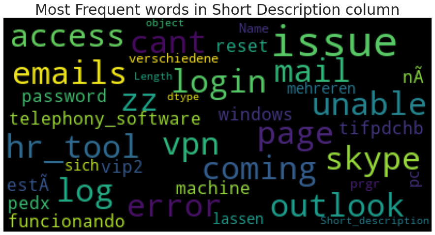

```python
wordCloudText(df_v1.Short_description, 'Short Description column')
```

```
<wordcloud.wordcloud.WordCloud object at 0x7fe04a63feb8>
```

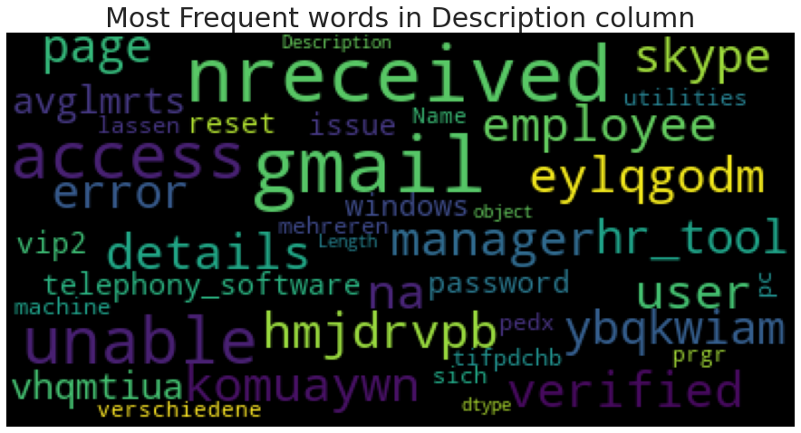

```python
wordCloudText(df_v1.Description, 'Description column')
```

The Caller column seems to be anonymised data (usernames/ids). This column will be dropped depending on the flag set at **DELETE_CALLER**.

```python
if DELETE_CALLER:
  df_v1 = df_v1.drop('Caller',axis=1)
else:
  df_v1['Caller'] = df_v1['Caller'].apply(lambda x: x.replace(" ", "_"))
df_v1.head(20)
```

|  | Short_description | Description | Group |
| --- | --- | --- | --- |
| 0 | login issue | -verified user details.(employee# & manager na... | GRP_0 |
| 1 | outlook | \r\n\r\nreceived from: hmjdrvpb.komuaywn@gmail... | GRP_0 |
| 2 | cant log in to vpn | \r\n\r\nreceived from: eylqgodm.ybqkwiam@gmail... | GRP_0 |
| 3 | unable to access hr_tool page | unable to access hr_tool page | GRP_0 |
| 4 | skype error | skype error | GRP_0 |
| 5 | unable to log in to engineering tool and skype | unable to log in to engineering tool and skype | GRP_0 |
| 6 | event: critical:HostName_221.company.com the v... | event: critical:HostName_221.company.com the v... | GRP_1 |
| 7 | ticket_no1550391- employment status - new non-... | ticket_no1550391- employment status - new non-... | GRP_0 |
| 8 | unable to disable add ins on outlook | unable to disable add ins on outlook | GRP_0 |
| 9 | ticket update on inplant_874773 | ticket update on inplant_874773 | GRP_0 |
| 10 | engineering tool says not connected and unable... | engineering tool says not connected and unable... | GRP_0 |
| 11 | hr_tool site not loading page correctly | hr_tool site not loading page correctly | GRP_0 |
| 12 | unable to login to hr_tool to sgxqsuojr xwbeso... | unable to login to hr_tool to sgxqsuojr xwbeso... | GRP_0 |
| 13 | user wants to reset the password | user wants to reset the password | GRP_0 |
| 14 | unable to open payslips | unable to open payslips | GRP_0 |
| 15 | ticket update on inplant_874743 | ticket update on inplant_874743 | GRP_0 |
| 16 | unable to login to company vpn | \n\nreceived from: xyz@company.com\n\nhi,\n\ni... | GRP_0 |
| 17 | when undocking pc , screen will not come back | when undocking pc , screen will not come back | GRP_3 |
| 18 | erp SID_34 account locked | erp SID_34 account locked | GRP_0 |
| 19 | unable to sign into vpn | unable to sign into vpn | GRP_0 |

```python
# Fetch rows with same data in "Short_description" & "Description"
df_v1[df_v1['Short_description'] == df_v1['Description']].count()
```

```
Short_description    2818
Description          2818
Group                2818
dtype: int64
```

Checking to see if Description and Short_description columns have same data, we see that there are 2818 records that have exactly same data in both the columns.

## Finding & Imputing Null values in Short Description & Description columns

```python
# Check for number of null values in each columns
print("Total Null Values in data:", df_v1.isnull().sum().sum())
print("\nNull Values accross columns:\n", df_v1.isnull().sum())
print("\nData with 'Null' Short Description")
df_v1.loc[df_v1['Short_description'].isnull()==True]
```

```
Total Null Values in data: 9

Null Values accross columns:
 Short_description    8
Description          1
Group                0
dtype: int64

Data with 'Null' Short Description
```

|  | Short_description | Description | Group |
| --- | --- | --- | --- |
| 2604 | NaN | \r\n\r\nreceived from: ohdrnswl.rezuibdt@gmail... | GRP_34 |
| 3383 | NaN | \r\n-connected to the user system using teamvi... | GRP_0 |
| 3906 | NaN | -user unable tologin to vpn.\r\n-connected to... | GRP_0 |
| 3910 | NaN | -user unable tologin to vpn.\r\n-connected to... | GRP_0 |
| 3915 | NaN | -user unable tologin to vpn.\r\n-connected to... | GRP_0 |
| 3921 | NaN | -user unable tologin to vpn.\r\n-connected to... | GRP_0 |
| 3924 | NaN | name:wvqgbdhm fwchqjor\nlanguage:\nbrowser:mic... | GRP_0 |
| 4341 | NaN | \r\n\r\nreceived from: eqmuniov.ehxkcbgj@gmail... | GRP_0 |

- There are 8 missing values in short description and 1 in Description columns.

```python
print("\nData with 'Null' Description")
df_v1.loc[df_v1['Description'].isnull()==True]
```

```
Data with 'Null' Description
```

|  | Short_description | Description | Group |
| --- | --- | --- | --- |
| 4395 | i am locked out of skype | NaN | GRP_0 |

Replacing the missing values with the common word 'the'.

```python
# Impute missing values
df_v1['Short_description'].fillna('the', inplace=True) # replacing null values with stopword 'the'
df_v1['Description'].fillna('the', inplace=True) # replacing null values with stopword 'the'

print("Null values imputed")
print("Null Values in data after imputation:", df_v1.isnull().sum().sum())
```

```
Null values imputed
Null Values in data after imputation: 0
```

## Visualizations

### Group data visualization

```python
#Creating dataframe of Groups on the basis of their value counts
n_grp = list(df_v1['Group'].value_counts())
grp_name = list(df_v1['Group'].value_counts().index)
grp = pd.DataFrame(data=grp_name,columns=['grp_name'])
grp['n_grp'] = n_grp
print(len(grp['n_grp']))
print(grp.head())
```

```
74
  grp_name  n_grp
0    GRP_0   3934
1    GRP_8    645
2   GRP_24    285
3   GRP_12    257
4    GRP_9    252
```

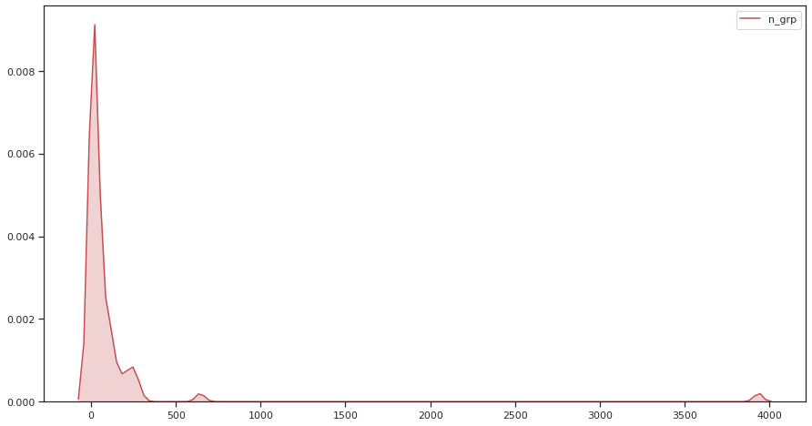

```python
# Checking the distribution of groups
plt.figure(figsize=(15,8))
sns.kdeplot(grp['n_grp'], shade=True, color="r")
```

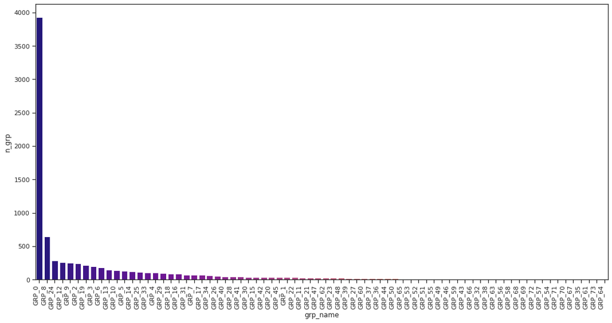

```python
plt.figure(figsize=(15,8))
sns.barplot(x="grp_name", y="n_grp", data=grp,palette='plasma')
plt.xticks(rotation=90, ha='right')
plt.tight_layout()
```

```python
fig = px.pie(grp,values='n_grp', names='grp_name')
fig.show()
```

[interactive chart not shown]

There are total of 74 groups to which tickets are assigned to. The ticket assignment is not symmetric and few groups have as minimum as one ticket assigned. The data has a class imbalance.

```python
# Reset Assignment Group for group types with less data
Frequency_Threshold = 1
count = df_v1['Group'].value_counts(ascending=True)
idx = count[count.lt(Frequency_Threshold)].index
df_v1.loc[df_v1['Group'].isin(idx), 'Group'] = 'GRP_Manual'
print("Updated unique group types",df_v1['Group'].nunique())
df_v1['Group'].value_counts(ascending=True)
```

```
Updated unique group types 74
```

```
GRP_64       1
GRP_73       1
GRP_61       1
GRP_35       1
GRP_67       1
          ...
GRP_9      252
GRP_12     257
GRP_24     285
GRP_8      645
GRP_0     3934
Name: Group, Length: 74, dtype: int64
```

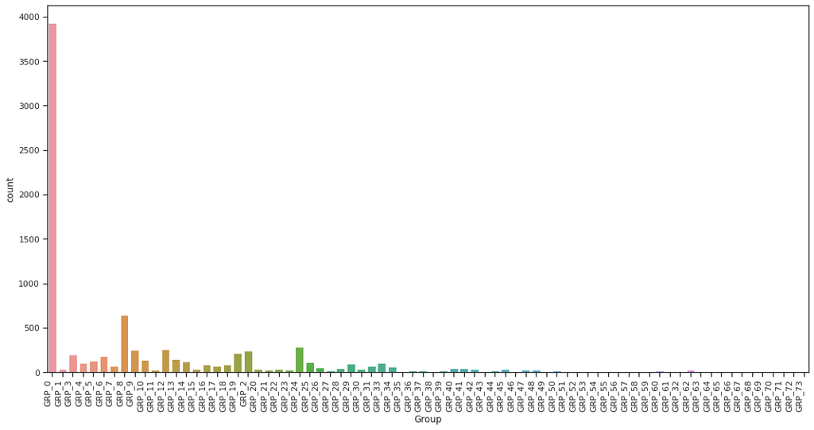

```python
plt.figure(figsize=(15,8))
sns.countplot(x="Group", data=df_v1)
plt.xticks(rotation=90, ha='right')
plt.tight_layout()
```

### Caller data visualization

We will analyse the caller data to understand this feature better.

```python
caller_data=pd.DataFrame(df['Caller'].value_counts().to_frame()).T
caller_data
```

|  | bpctwhsn kzqsbmtp | ZkBogxib QsEJzdZO | fumkcsji sarmtlhy | rbozivdq gmlhrtvp | rkupnshb gsmzfojw | jloygrwh acvztedi | spxqmiry zpwgoqju | oldrctiu bxurpsyi | olckhmvx pcqobjnd | jyoqwxhz clhxsoqy | dkmcfreg anwmfvlg | efbwiadp dicafxhv | afkstcev utbnkyop | gzhapcld fdigznbk | mnlazfsr mtqrkhnx | uvrbhlnt bjrmalzi | entuakhp xrnhtdmk | jionmpsf wnkpzcmv | vzqomdgt jwoqbuml | bozdftwx smylqejw | qasdhyzm yuglsrwx | utyeofsk rdyzpwhi | rxoynvgi ntgdsehl | vbwszcqn nlbqsuyv | ugyothfz ugrmkdhx | hbmwlprq ilfvyodx | ughzilfm cfibdamq | niptbwdq csenjruz | vfrdxtqw jfbmsenz | … |
| --- | --- | --- | --- | --- | --- | --- | --- | --- | --- | --- | --- | --- | --- | --- | --- | --- | --- | --- | --- | --- | --- | --- | --- | --- | --- | --- | --- | --- | --- | --- |
| Caller | 810 | 151 | 134 | 87 | 71 | 64 | 63 | 57 | 54 | 51 | 51 | 45 | 32 | 30 | 28 | 27 | 25 | 24 | 24 | 23 | 21 | 21 | 21 | 19 | 17 | 17 | 16 | 16 | 16 | … |

1 rows × 2950 columns

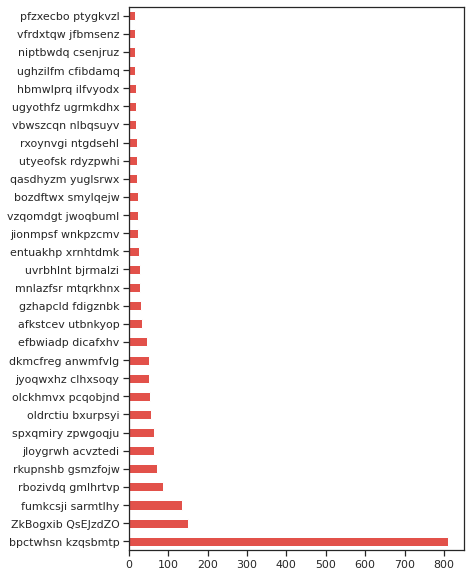

```python
#Visualizing some of the Caller data with anonymous names
plt.figure(figsize=(20, 10))
df['Caller'].value_counts().head(30).plot(kind='barh', figsize=(6,10))
```

```python
#Creating dataframe of callers on the basis of their frequency of calling
n_caller = list(df['Caller'].value_counts())
caller = list(df['Caller'].value_counts().index)

data = pd.DataFrame(data=caller,columns=['caller'])
data['n_caller'] = n_caller
len(data['caller'])
```

```
2950
```

```python
#Since caller column contains anonymous data, assigning name Caller1, Caller2,..... for better visualization
count = 0
new_caller = []
while count != len(data):
    new_caller.append('Caller'+''+ str(count+1))
    count = count +1
data['caller'] = new_caller
data = data.head(20)
data.head(10)
```

|  | caller | n_caller |
| --- | --- | --- |
| 0 | Caller1 | 810 |
| 1 | Caller2 | 151 |
| 2 | Caller3 | 134 |
| 3 | Caller4 | 87 |
| 4 | Caller5 | 71 |
| 5 | Caller6 | 64 |
| 6 | Caller7 | 63 |
| 7 | Caller8 | 57 |
| 8 | Caller9 | 54 |
| 9 | Caller10 | 51 |

```python
#top 20 callers
fig = px.bar(data, x='caller', y='n_caller',hover_data=['n_caller'])
fig.show()
```

[interactive chart not shown]

Analysing the caller data, we see that one caller has reported 810 tickets, and the distribution is skewed. This could be a batch job or an anomaly and should be considered for discussion with domain expert. We are not taking up further analysis of caller for this project, for now.

## Text Cleaning

```python
import string
import re

# Function for Text Cleaning with regex. Pass the column
def text_preprocessing(df_column):
  data = df_column.values.tolist() # Convert to list
  temp = []
  for sentence in data:
      sentence = sentence.replace("select the following link to view the disclaimer in an alternate language", '')  # remove disclaimer text
      sentence = re.sub(r"\[(.*?)\]"," ", sentence)  # remove text in []
      sentence = re.sub(r"\((.*?)\)"," ", sentence)  # remove text in ()
      sentence = re.sub(r"[[h][t][t][p][\S]+|[w][w][w][\S]+|[\S]+[@][\S]+"," ", sentence)  # remove email addresses, web address and urls
      sentence = re.sub(r"[\S]+[\d]+[\S]+"," ", sentence) # remove alphanumerics and numerics (dates, time, request id etc.)
      sentence = re.sub(r"\W(?<!['. ])"," ", sentence)  # remove all non words with negative look back except ('. spaces)
      sentence = re.sub(r"[^a-zA-z.| ]+"," ", sentence) # remove non-alphabetic text
      sentence = re.sub(r"[\_]+"," ", sentence) # remove underscores
      sentence = re.sub(r"[\s]+"," ", sentence) # replace multiple spaces with single space
      sentence = sentence.strip('\n')
      sentence = sentence.lower()
      temp.append(sentence)
  return(temp)
```

```python
# Cleaned both - 'Short_Description & Description'
df_v1.Short_description = text_preprocessing(df_v1.Short_description)
df_v1.Description = text_preprocessing(df_v1.Description)
df_v1.head()
```

|  | Short_description | Description | Group |
| --- | --- | --- | --- |
| 0 | login issue | verified user details. checked the user name ... | GRP_0 |
| 1 | outlook | received from hello team my meetings skype me... | GRP_0 |
| 2 | cant log in to vpn | received from hi i cannot log on to vpn best | GRP_0 |
| 3 | unable to access hr tool page | unable to access hr tool page | GRP_0 |
| 4 | skype error | skype error | GRP_0 |

After cleaning text in Short_description and Description column, the dataset looks as above. Information in both the columns are contributor for classification. Hence we concatenate these two columns so that no information is lost

## Concatenating "Short Description" and "Description" to get "Summary" Tickets

```python
if DELETE_CALLER == False:
  df_v1["Summary"] = df_v1['Short_description'].str.cat(df_v1['Description'], sep = ". ")
  df_v1["Summary"] = df_v1['Summary'].str.cat(df_v1['Caller'], sep = ". ")
else:
  df_v1["Summary"] = df_v1['Short_description'].str.cat(df_v1['Description'], sep = ". ")

df_v2 = df_v1[['Group','Summary']]
df_v2.head(5)
```

|  | Group | Summary |
| --- | --- | --- |
| 0 | GRP_0 | login issue. verified user details. checked t... |
| 1 | GRP_0 | outlook. received from hello team my meetings... |
| 2 | GRP_0 | cant log in to vpn. received from hi i cannot... |
| 3 | GRP_0 | unable to access hr tool page. unable to acces... |
| 4 | GRP_0 | skype error . skype error |

**Visualizing the Cleaned data in Summary Column through Word Cloud**

```
<wordcloud.wordcloud.WordCloud object at 0x7fe044400898>
```

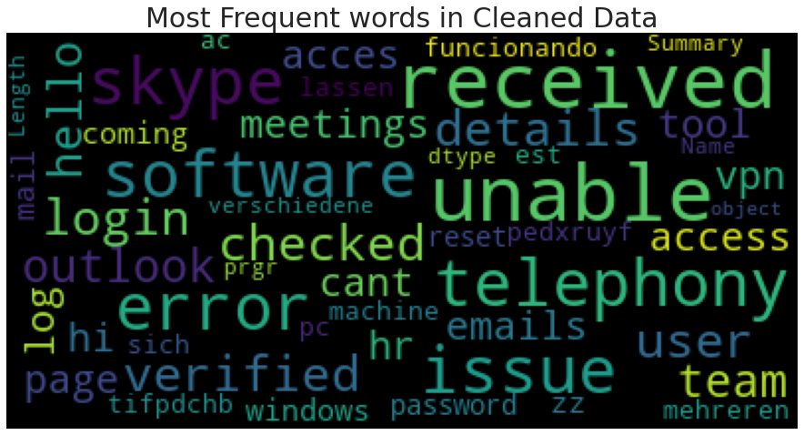

```python
wordCloudText(df_v2.Summary, 'Cleaned Data')
```

### Stop words Removal, Tokenization and Lemmatization

```python
# word tokenisation & removal of stop words & gibberish word(by typos, anonymised names)

# Remove stopwords
df_v2['Summary'] = df_v2['Summary'].apply(lambda x: ' '.join([word for word in x.split() if word not in (stop_words)]))

# Remove words not in Englsih Dictionary (typos, anonymised names)
df_v2['Summary'] = df_v2['Summary'].apply(lambda x: ' '.join([word for word in x.split() if word in (words)]))

# Tokenise 'Summary' column
data = df_v2.Summary.values.tolist()
data = [list(tokenize(sentences)) for sentences in data]

# lemmetise words
wordnet_lemmatizer = WordNetLemmatizer()
temp = []
for eachrow in data:
    lemma_words = []
    for eachword in eachrow:
        eachword = wordnet_lemmatizer.lemmatize(eachword, pos = "n")
        eachword = wordnet_lemmatizer.lemmatize(eachword, pos = "v")
        eachword = wordnet_lemmatizer.lemmatize(eachword, pos = ("a"))
        lemma_words.append(eachword)
    temp.append(lemma_words)
data = temp

data = [(" ".join(sentence))  for sentence in data]

df_v2['Summary'] = data

#cleaned data
df_v3 = df_v2.copy()
# If EXCLUDE_CALLER is set to False then add Caller information to Summary (usernames/ids).
if not(EXCLUDE_CALLER):
  df_v3['Caller'] =  df['Caller']
  df_v3['Caller'] =  df_v3['Caller'].apply(lambda x: x.replace(" ", "_"))
  df_v3["Summary"] = df_v3['Summary'].str.cat(df_v3['Caller'], sep = ". ")
df_v3.drop(['Caller'], axis=1, inplace=True)
df_lstm = df_v3 # Saved for lstm model

#cleaned data
df_v2
```

|  | Group | Summary |
| --- | --- | --- |
| 0 | GRP_0 | login user check user name ad reset advise use... |
| 1 | GRP_0 | receive team outlook calendar somebody advise ... |
| 2 | GRP_0 | cant log receive cannot log |
| 3 | GRP_0 | unable access tool unable access tool page |
| 4 | GRP_0 | error error |
| ... | ... | ... |
| 8495 | GRP_29 | come receive good afternoon send advise |
| 8496 | GRP_0 | telephony telephony issue |
| 8497 | GRP_0 | password reset password reset |
| 8498 | GRP_62 | machine n unable access machine finish drawer ... |
| 8499 | GRP_49 |  |

8417 rows × 2 columns

### TF-IDF WITHOUT SAMPLING

In this project we will use tf-idf to transforms text to feature vectors.

```python
maxlen = 0
for sentence in data:
    if (maxlen < sentence.count(' ')+1 ):
        maxlen = sentence.count(' ')+1

print(maxlen)

# Create Weighted Word Vectors
tfidf_vectors = TfidfVectorizer(min_df=3,max_features= maxlen)
tfidf_db = tfidf_vectors.fit_transform(data).toarray()
tfidf_db = pd.DataFrame(tfidf_db)
```

```
367
```

```python
tfidf_db.head()
```

|  | 0 | 1 | 2 | 3 | 4 | 5 | 6 | 7 | 8 | 9 | 10 | 11 | 12 | 13 | 14 | 15 | 16 | 17 | 18 | 19 | 20 | 21 | 22 | 23 | 24 | 25 | 26 | 27 | 28 | … |
| --- | --- | --- | --- | --- | --- | --- | --- | --- | --- | --- | --- | --- | --- | --- | --- | --- | --- | --- | --- | --- | --- | --- | --- | --- | --- | --- | --- | --- | --- | --- |
| 0 | 0.214289 | 0.000000 | 0.0 | 0.0 | 0.0 | 0.0 | 0.0 | 0.287878 | 0.0 | 0.0 | 0.0 | 0.278380 | 0.0 | 0.0 | 0.0 | 0.0 | 0.0 | 0.0 | 0.0 | 0.0 | 0.0 | 0.0 | 0.0 | 0.0 | 0.0 | 0.0 | 0.0 | 0.0 | 0.0 | … |
| 1 | 0.000000 | 0.000000 | 0.0 | 0.0 | 0.0 | 0.0 | 0.0 | 0.000000 | 0.0 | 0.0 | 0.0 | 0.529839 | 0.0 | 0.0 | 0.0 | 0.0 | 0.0 | 0.0 | 0.0 | 0.0 | 0.0 | 0.0 | 0.0 | 0.0 | 0.0 | 0.0 | 0.0 | 0.0 | 0.0 | … |
| 2 | 0.000000 | 0.000000 | 0.0 | 0.0 | 0.0 | 0.0 | 0.0 | 0.000000 | 0.0 | 0.0 | 0.0 | 0.000000 | 0.0 | 0.0 | 0.0 | 0.0 | 0.0 | 0.0 | 0.0 | 0.0 | 0.0 | 0.0 | 0.0 | 0.0 | 0.0 | 0.0 | 0.0 | 0.0 | 0.0 | … |
| 3 | 0.000000 | 0.549125 | 0.0 | 0.0 | 0.0 | 0.0 | 0.0 | 0.000000 | 0.0 | 0.0 | 0.0 | 0.000000 | 0.0 | 0.0 | 0.0 | 0.0 | 0.0 | 0.0 | 0.0 | 0.0 | 0.0 | 0.0 | 0.0 | 0.0 | 0.0 | 0.0 | 0.0 | 0.0 | 0.0 | … |
| 4 | 0.000000 | 0.000000 | 0.0 | 0.0 | 0.0 | 0.0 | 0.0 | 0.000000 | 0.0 | 0.0 | 0.0 | 0.000000 | 0.0 | 0.0 | 0.0 | 0.0 | 0.0 | 0.0 | 0.0 | 0.0 | 0.0 | 0.0 | 0.0 | 0.0 | 0.0 | 0.0 | 0.0 | 0.0 | 0.0 | … |

5 rows × 367 columns

```python
#viewing list of data
data[0:10]
```

```
['login user check user name ad reset advise user login caller confirm able issue',
 'receive team outlook calendar somebody advise correct',
 'cant log receive cannot log',
 'unable access tool unable access tool page',
 'error error',
 'unable log engineer tool unable log engineer tool',
 'event value threshold event value threshold',
 'employment status new non employee employment status new non employee',
 'unable disable add unable disable add outlook',
 'ticket update ticket update']
```

### Label Encoding

```python
le = preprocessing.LabelEncoder()
df_v2['Group']= le.fit_transform(df_v2['Group']) # LabelEncode 'Groups'
df_v3['Group']= le.fit_transform(df_v3['Group']) # LabelEncode 'Groups'
df_v2.head(20)
```

|  | Group | Summary |
| --- | --- | --- |
| 0 | 0 | login user check user name ad reset advise use... |
| 1 | 0 | receive team outlook calendar somebody advise ... |
| 2 | 0 | cant log receive cannot log |
| 3 | 0 | unable access tool unable access tool page |
| 4 | 0 | error error |
| 5 | 0 | unable log engineer tool unable log engineer tool |
| 6 | 1 | event value threshold event value threshold |
| 7 | 0 | employment status new non employee employment ... |
| 8 | 0 | unable disable add unable disable add outlook |
| 9 | 0 | ticket update ticket update |
| 10 | 0 | engineer tool connect unable submit engineer t... |
| 11 | 0 | tool site load page tool site load page correctly |
| 12 | 0 | unable login tool unable login tool |
| 13 | 0 | user reset user reset password |
| 14 | 0 | unable open unable open |
| 15 | 0 | ticket update ticket update |
| 16 | 0 | unable login company receive unable login comp... |
| 17 | 23 | screen come screen come back |
| 18 | 0 | account account lock |
| 19 | 0 | unable sign unable sign |

## Train and test split for original data

```python
X1 = tfidf_db
y1 = df_v2['Group']

X_train1, X_test1, y_train1, y_test1 = train_test_split(X1, y1, test_size=0.40, random_state=42)
```

# Sampling Minority Class using RandomOverSampler

To address imbalanced class in this project, we will upsample minority classes downsample the major class.

```python
# Getting the dataset ready (X and y)
# X and y for Upsampling and Downsampling
Sampled_df = df_v2
Sampled_df.shape
```

```
(8417, 2)
```

```python
Sampled_df
```

|  | Group | Summary |
| --- | --- | --- |
| 0 | 0 | login user check user name ad reset advise use... |
| 1 | 0 | receive team outlook calendar somebody advise ... |
| 2 | 0 | cant log receive cannot log |
| 3 | 0 | unable access tool unable access tool page |
| 4 | 0 | error error |
| ... | ... | ... |
| 8495 | 22 | come receive good afternoon send advise |
| 8496 | 0 | telephony telephony issue |
| 8497 | 0 | password reset password reset |
| 8498 | 59 | machine n unable access machine finish drawer ... |
| 8499 | 44 |  |

8417 rows × 2 columns

```python
# Checking shape of major class group 0 records
Sampled_df_maj = Sampled_df[(Sampled_df['Group'] == 0)]
print("X shape = %f",Sampled_df_maj.shape)
```

```
X shape = %f (3934, 2)
```

```python
# Picking records from the Major class group 0 randomly
Sampled_df_maj = Sampled_df_maj.sample(frac = 0.25)
print("X shape = %f",Sampled_df_maj.shape)
```

```
X shape = %f (984, 2)
```

```python
#Picking records other than major class group 0
Sampled_df_bal = Sampled_df[(Sampled_df['Group'] != 0)]
Sampled_df_bal.shape
```

```
(4483, 2)
```

```python
#Storing major class downsampled data and remaining class data in dataframe
sets_x = [Sampled_df_bal,Sampled_df_maj]
Sampled_df = pd.concat(sets_x)
print("Dataset shape = %f",Sampled_df.shape)
```

```
Dataset shape = %f (5467, 2)
```

```python
Sampled_df
```

|  | Group | Summary |
| --- | --- | --- |
| 6 | 1 | event value threshold event value threshold |
| 17 | 23 | screen come screen come back |
| 32 | 34 | duplication network receive two try share try ... |
| 43 | 45 | reroute issue need resolve receive printer wor... |
| 47 | 56 | job job receive job job |
| ... | ... | ... |
| 7544 | 0 | reset password production reset password |
| 4336 | 0 | account unlock password account unlock passwor... |
| 8217 | 0 | guest access receive follow guest visit compan... |
| 7251 | 0 | trigger show summary actually trigger show |
| 5227 | 0 | account account unlock |

5467 rows × 2 columns

## Shuffling rows after concat operation

```python
#Shuffling rows of data for better splitting of groups in test and train
Sampled_df = Sampled_df.sample(frac=1, axis=0).reset_index(drop=True)
Sampled_df
```

|  | Group | Summary |
| --- | --- | --- |
| 0 | 22 | pending status receive help desk pending day y... |
| 1 | 0 | need map need map |
| 2 | 37 | flecken den flecken den |
| 3 | 6 | currently high investigate observe alert tool ... |
| 4 | 18 | engineer tool receive new customer addition bu... |
| ... | ... | ... |
| 5462 | 0 | need file welcome next available agent interac... |
| 5463 | 72 | job job receive job job |
| 5464 | 4 | use login company via use login company via as... |
| 5465 | 73 | receive someone check fix rep available check ... |
| 5466 | 2 | help delete payment run code help delete payme... |

5467 rows × 2 columns

```python
#Creating X and y for upsmpling
Sampled_df_x = Sampled_df.drop(["Group"], axis = 1, inplace = False)
Sampled_df_y = Sampled_df.drop(["Summary"], axis = 1, inplace = False)
Sampled_df_x.head()
```

|  | Summary |
| --- | --- |
| 0 | pending status receive help desk pending day y... |
| 1 | need map need map |
| 2 | flecken den flecken den |
| 3 | currently high investigate observe alert tool ... |
| 4 | engineer tool receive new customer addition bu... |

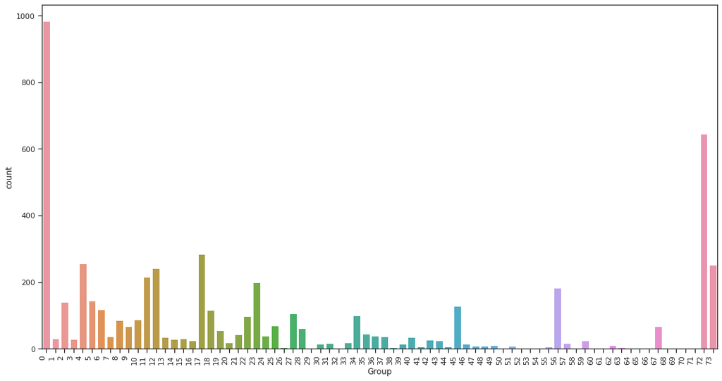

```python
#Plotting undersampled major class group 0 with remaining class group
plt.figure(figsize=(15,8))
sns.countplot(Sampled_df['Group'])
plt.xticks(rotation=90, ha='right')
plt.tight_layout()
```

```python
#Performing oversampling of all groups for sufficient count of all group types
ros = RandomOverSampler()
X_ros, y_ros = ros.fit_sample(Sampled_df_x, Sampled_df_y)

print("X shape = %f",X_ros.shape)
print("Y shape = %f",y_ros.shape)
```

```
X shape = %f (72816, 1)
Y shape = %f (72816,)
```

```python
df_x = pd.DataFrame(X_ros)
df_y = pd.DataFrame(y_ros)
df_x.shape
```

```
(72816, 1)
```

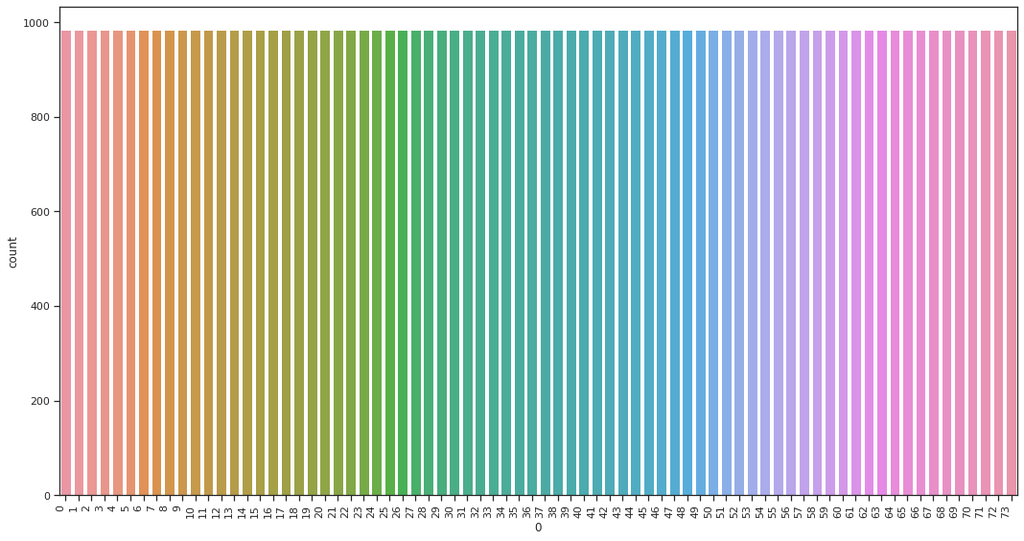

```python
# Checking the distribution of groups after oversampling
plt.figure(figsize=(15,8))
sns.countplot(df_y[0])
plt.xticks(rotation=90, ha='right')
plt.tight_layout()
```

```python
data1 = df_x[0].values.tolist()
data1 = [list(tokenize(sentences)) for sentences in data1]
len(data1)
data1 = [(" ".join(sentence))  for sentence in data1]

# Create Weighted Word Vectors for oversampled data
tfidf_vectors1 = TfidfVectorizer(max_features= maxlen)
tfidf_db1 = tfidf_vectors1.fit_transform(data1).toarray()
tfidf_db1 = pd.DataFrame(tfidf_db1)
tfidf_db1.shape
```

```
(72816, 367)
```

# Simple splitting of the oversampled data into Training and Testing sets

**Train and test split**

```python
X = tfidf_db1
y = df_y

X_train, X_test, y_train, y_test = train_test_split(X, y, test_size=0.30, random_state=42)
```

```python
X_train.shape
```

```
(50971, 367)
```

# Model Building

For this dataset, we will build some traditional models and RNN.

- Multnomial Naive Bayes
- Support Vector Machine
- Decision Tree
- Random Forest
- Ensemble
- LSTM
- DNN
- RCNN

## Importing packages for Model Building

```python
#import all the packages
from sklearn.naive_bayes import MultinomialNB
from sklearn.svm import SVC
from sklearn.tree import DecisionTreeClassifier
from sklearn.ensemble import RandomForestClassifier
from sklearn.ensemble import BaggingClassifier, ExtraTreesClassifier, RandomForestClassifier
from sklearn.neighbors import KNeighborsClassifier
from sklearn.linear_model import RidgeClassifier
from sklearn.model_selection import cross_val_score
from sklearn.ensemble import VotingClassifier
from sklearn.ensemble import AdaBoostClassifier
from sklearn.ensemble import GradientBoostingClassifier
from xgboost import XGBClassifier
from mlxtend.classifier import EnsembleVoteClassifier
from sklearn.metrics import classification_report, confusion_matrix, precision_score, recall_score, f1_score
from sklearn.model_selection import cross_validate, ShuffleSplit
from sklearn.metrics import accuracy_score
#import Grid Search
from sklearn.model_selection import GridSearchCV
# ROC AUC
from sklearn.metrics import roc_auc_score
from sklearn.preprocessing import LabelBinarizer
```

```python
# Creating Dataframe to save results for each executed model
result_df = pd.DataFrame(columns=['Model', 'Test_Accuracy'])
result_df['Model']=['NB','SVM','D-Tree','RandomForest','Bagging_Ensemble','Boosting_Ensemble','LSTM','DNN','RCNN']
```

## Multinomial Naive Bayes

```python
# Multinomial Naive Bayes
NBModel = MultinomialNB(alpha = 0.001)
NBModel.fit(X_train1, y_train1)
NB_y_pred = NBModel.predict(X_test1)
print('NB Training Accuracy:', 100*NBModel.score(X_train1 , y_train1))
print('NB Test Accuracy:', 100*NBModel.score(X_test1 , y_test1))

# Update model results in result dataframe
loc = result_df[result_df['Model']=='NB'].index
result_df['Test_Accuracy'][loc] = (NBModel.score(X_test1 , y_test1))
```

```
NB Training Accuracy: 67.48514851485149
NB Test Accuracy: 59.16245916245916
```

```python
print ('Precision Score:', precision_score(y_test1, NB_y_pred, pos_label='Positive', average='weighted'))
print ('Recall Score:', recall_score(y_test1, NB_y_pred, pos_label='Positive', average='weighted'))
F1score = f1_score(NB_y_pred, y_test1, average='weighted')
print('F1 Score:', F1score)
print(confusion_matrix(y_test1,NB_y_pred))
print(classification_report(y_test1,NB_y_pred))
```

```
Precision Score: 0.4920015417672563
Recall Score: 0.5916245916245916
F1 Score: 0.6825936416238768
[[1536    0    0 ...    0    2    0]
 [   5    0    0 ...    0    4    0]
 [  19    0   20 ...    0    6    1]
 ...
 [   1    0    0 ...    0    0    0]
 [  13    0    2 ...    0  213    0]
 [  17    0    1 ...    0   80    0]]
              precision    recall  f1-score   support

           0       0.64      0.96      0.76      1600
           1       0.00      0.00      0.00        13
           2       0.71      0.37      0.49        54
```

[output cut: 67 more lines]

## Support Vector Machine

```python
# Creating SVC Model
svm_model = SVC(kernel='linear',C=10)
svm_model.fit(X_train1, y_train1)
y_pred = svm_model.predict(X_test1)
print('Training Accuracy:', 100*svm_model.score(X_train1 , y_train1))
print('Test Accuracy:',100*svm_model.score(X_test1 , y_test1))

# Update model results in result dataframe
loc = result_df[result_df['Model']=='SVM'].index
result_df['Test_Accuracy'][loc] = (svm_model.score(X_test1, y_test1))
```

```
Training Accuracy: 80.81188118811882
Test Accuracy: 59.90495990495991
```

```python
print ('Precision Score:', precision_score(y_test1, y_pred, pos_label='Positive', average='weighted'))
print ('Recall Score:', recall_score(y_test1, y_pred, pos_label='Positive', average='weighted'))

F1score = f1_score(y_pred, y_test1, average='weighted')
print('F1 Score:', F1score)
print(confusion_matrix(y_test1,y_pred))
print(classification_report(y_test1,y_pred))
```

```
Precision Score: 0.5334697958816119
Recall Score: 0.5990495990495991
F1 Score: 0.6526086112948942
[[1417    0    1 ...    0    2    8]
 [   1    0    0 ...    0    4    0]
 [  12    0   28 ...    0    6    0]
 ...
 [   1    0    0 ...    0    0    0]
 [   4    0    2 ...    0  218    1]
 [   9    0    0 ...    0   80    5]]
              precision    recall  f1-score   support

           0       0.73      0.89      0.80      1600
           1       0.00      0.00      0.00        13
           2       0.68      0.52      0.59        54
```

[output cut: 67 more lines]

## Decision Tree

```python
# Using Decision Tree Classifier
dt_model = DecisionTreeClassifier(criterion = 'entropy' )
dt_model.fit(X_train1, y_train1)
```

```
DecisionTreeClassifier(ccp_alpha=0.0, class_weight=None, criterion='entropy',
                       max_depth=None, max_features=None, max_leaf_nodes=None,
                       min_impurity_decrease=0.0, min_impurity_split=None,
                       min_samples_leaf=1, min_samples_split=2,
                       min_weight_fraction_leaf=0.0, presort='deprecated',
                       random_state=None, splitter='best')
```

```python
y_predict = dt_model.predict(X_test1)
print('Training Accuracy:',100*dt_model.score(X_train1, y_train1))
print('Test Accuracy:',100*dt_model.score(X_test1 , y_test1))
loc = result_df[result_df['Model']=='D-Tree'].index
result_df['Test_Accuracy'][loc] = (dt_model.score(X_test , y_test))
```

```
Training Accuracy: 88.47524752475248
Test Accuracy: 51.559251559251564
```

```python
print ('Precision Score:', precision_score(y_test1, y_predict, pos_label='Positive', average='weighted'))
print ('Recall Score:', recall_score(y_test1, y_predict, pos_label='Positive', average='weighted'))

F1score = f1_score(y_predict, y_test1, average='weighted')
print('F1 Score:', F1score)
print(confusion_matrix(y_test1,y_predict))
print(classification_report(y_test1,y_predict))
```

```
Precision Score: 0.4558184061208864
Recall Score: 0.5155925155925156
F1 Score: 0.5581885771705958
[[1249    1    2 ...    1    8   16]
 [   3    2    0 ...    0    4    0]
 [  18    0   18 ...    0    6    0]
 ...
 [   0    0    0 ...    0    0    0]
 [   8    1    2 ...    0  199    0]
 [   7    0    0 ...    1   80    1]]
              precision    recall  f1-score   support

           0       0.70      0.78      0.74      1600
           1       0.13      0.15      0.14        13
           2       0.72      0.33      0.46        54
```

[output cut: 69 more lines]

## Random Forest Classifier

```python
#Using Random Forest Classifier
rfcl = RandomForestClassifier(criterion = 'entropy', n_estimators = 50)
rfcl = rfcl.fit(X_train1, y_train1)
test_pred = rfcl.predict(X_test1)
print('Training Accuracy:', 100*rfcl.score(X_train1 , y_train1))
print('Test Accuracy:',100*rfcl.score(X_test1 , y_test1))
loc = result_df[result_df['Model']=='RandomForest'].index
result_df['Test_Accuracy'][loc] = (rfcl.score(X_test , y_test))
```

```
Training Accuracy: 88.41584158415841
Test Accuracy: 59.07335907335908
```

```python
print ('Precision Score:', precision_score(y_test1, test_pred, pos_label='Positive', average='weighted'))
print ('Recall Score:', recall_score(y_test1, test_pred, pos_label='Positive', average='weighted'))

F1score = f1_score(test_pred, y_test1, average='weighted')
print('F1 Score:', F1score)
print(confusion_matrix(y_test1,test_pred))
print(classification_report(y_test1,test_pred))
```

```
Precision Score: 0.5088243841615672
Recall Score: 0.5907335907335908
F1 Score: 0.6802366134101724
[[1504    0    0 ...    0    1    1]
 [   4    1    0 ...    0    5    0]
 [  27    0   18 ...    0    6    0]
 ...
 [   1    0    0 ...    0    0    0]
 [  12    0    2 ...    0  208    0]
 [  16    0    0 ...    0   80    1]]
              precision    recall  f1-score   support

           0       0.65      0.94      0.77      1600
           1       0.25      0.08      0.12        13
           2       0.90      0.33      0.49        54
```

[output cut: 67 more lines]

## Ensemble Techniques

### Voting Classifier with Bagging

```python
rf = RandomForestClassifier()
et = ExtraTreesClassifier()
knn = KNeighborsClassifier()
svc = SVC()
rg = RidgeClassifier()
```

```python
# Ensemble of Bagging Classifiers
clf = [rf, et, knn, svc, rg]
eclf = VotingClassifier(estimators=[('Random Forests', rf), ('Extra Trees', et), ('KNeighbors', knn), ('SVC', svc),
                                    ('Ridge Classifier', rg)], voting='hard')
for clf, label in zip([rf, et, knn, svc, rg, eclf], ['Random Forest', 'Extra Trees', 'KNeighbors', 'SVC',
                                                     'Ridge Classifier', 'Ensemble']):
    scores = cross_val_score(clf, X_train1, y_train1, cv=10, scoring='accuracy')
    test_accuracy = round(scores.mean(),2)
    print("Accuracy: %0.2f (+/- %0.2f) [%s]" % (test_accuracy, scores.std(), label))

# Update model results in result dataframe
loc = result_df[result_df['Model']=='Bagging_Ensemble'].index
result_df['Test_Accuracy'][loc] = test_accuracy
```

```
Accuracy: 0.60 (+/- 0.01) [Random Forest]
Accuracy: 0.60 (+/- 0.01) [Extra Trees]
Accuracy: 0.58 (+/- 0.01) [KNeighbors]
Accuracy: 0.60 (+/- 0.01) [SVC]
Accuracy: 0.59 (+/- 0.01) [Ridge Classifier]
Accuracy: 0.61 (+/- 0.01) [Ensemble]
```

### Boosting Classifier

```python
# Ensemble of Boosting Classifiers
ada_boost = AdaBoostClassifier()
grad_boost = GradientBoostingClassifier()
xgb_boost = XGBClassifier()

boost_array = [ada_boost, grad_boost, xgb_boost]
eclf = EnsembleVoteClassifier(clfs=[ada_boost, grad_boost, xgb_boost], voting='hard')
labels = ['Ada Boost', 'Grad Boost', 'XG Boost', 'Ensemble']
for clf, label in zip([ada_boost, grad_boost, xgb_boost, eclf], labels):
    scores = cross_val_score(clf, X_train1, y_train1, cv=10, scoring='accuracy')
    test_accuracy = round(scores.mean(),2)
    print("Mean: {0:.2f} of [{1}]".format(test_accuracy, label))

# Update model results in result dataframe
loc = result_df[result_df['Model']=='Boosting_Ensemble'].index
result_df['Test_Accuracy'][loc] = test_accuracy
```

```
Mean: 0.51 of [Ada Boost]
Mean: 0.56 of [Grad Boost]
Mean: 0.59 of [XG Boost]
Mean: 0.58 of [Ensemble]
```

# Model Tuning

We will fine tune all the models built to see if we can improve the performance

### Multinomial Naive Bayes

```python
def find_optimal_k(X,y, lr_list):
  # empty list that will hold cv scores
  scores = []
  for lr in lr_list:
    model_nb = MultinomialNB(alpha = lr)
    model = model_nb.fit(X_train1, y_train1)
    # predict the response on the crossvalidation train
    predict = model.predict(X_test1)

    # evaluate accuracy
    accuracy = accuracy_score(y_test1, predict, normalize=True)
    scores.append(accuracy)

    # changing to misclassification error
    mean_square_error = [1 - x for x in scores]

  # determining best alpha
  optimal_alpha = lr_list[mean_square_error.index(min(mean_square_error))]
  print('\nThe optimal alpha is ', optimal_alpha)

  plt.figure(figsize=(10,6))
  plt.plot(lr_list, mean_square_error,color='blue', linestyle='dashed', marker='o', markerfacecolor='red', markersize=10)
  plt.title('Error Rate vs. alpha Value')
  plt.xlabel('alpha')
  plt.ylabel('Error Rate')

  print("the misclassification error for each k value is : ", np.round(mean_square_error,3))

  return optimal_alpha
```

```
The optimal alpha is  0.00098
the misclassification error for each k value is :  [0.414 0.413 0.413 0.413 0.413 0.413 0.413 0.413 0.413 0.413 0.413 0.413
 0.413 0.413 0.413 0.413 0.413 0.413 0.413 0.413 0.413 0.413 0.413 0.412
 0.412 0.412 0.412 0.412 0.412 0.412 0.412 0.412 0.412 0.411 0.411 0.411
 0.411 0.411 0.411 0.411 0.411 0.411 0.411 0.411 0.411 0.411 0.411 0.411
 0.411 0.411 0.41  0.41  0.41  0.41  0.41  0.41  0.41  0.41  0.41  0.41
 0.41  0.41  0.41  0.41  0.41  0.41  0.41  0.41  0.41  0.41  0.41  0.41
 0.41  0.41  0.41  0.41  0.41  0.41  0.41  0.41  0.41  0.41  0.41  0.409
 0.409 0.409 0.409 0.409 0.409 0.409 0.409 0.409 0.409 0.409 0.409 0.409
 0.409 0.409 0.409]
The optimal K found is:  0.00098
```

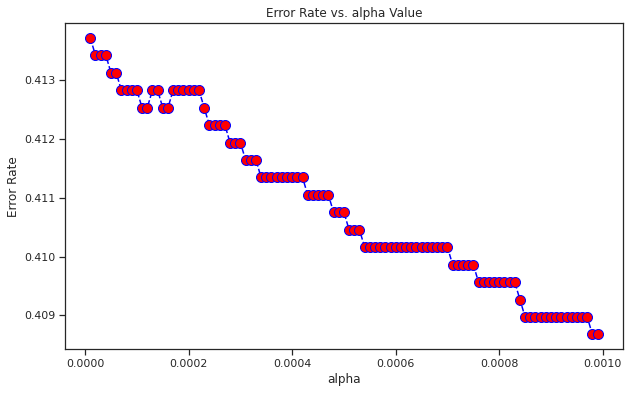

```python
lr_lst = np.arange(0.00001, 0.001, 0.00001)
best_lr = find_optimal_k(X_train1 ,y_train1, lr_lst)
print("The optimal K found is: ", best_lr)
```

```python
Tuned_NBModel = MultinomialNB(alpha = best_lr)
Tuned_NBModel.fit(X_train1, y_train1)
NB_y_pred = Tuned_NBModel.predict(X_test1)
print('NB Training Accuracy:', 100*Tuned_NBModel.score(X_train1 , y_train1))
print('NB Test Accuracy:', 100*Tuned_NBModel.score(X_test1 , y_test1))
```

```
NB Training Accuracy: 67.48514851485149
NB Test Accuracy: 59.132759132759126
```

```python
print ('Precision Score:', precision_score(y_test1, NB_y_pred, pos_label='Positive', average='weighted'))
print ('Recall Score:', recall_score(y_test1, NB_y_pred, pos_label='Positive', average='weighted'))
F1score = f1_score(NB_y_pred, y_test1, average='weighted')
print('F1 Score:', F1score)
print(confusion_matrix(y_test1,NB_y_pred))
print(classification_report(y_test1,NB_y_pred))
```

```
Precision Score: 0.4910393770412011
Recall Score: 0.5913275913275913
F1 Score: 0.6825311058379618
[[1536    0    0 ...    0    2    0]
 [   5    0    0 ...    0    4    0]
 [  19    0   20 ...    0    6    1]
 ...
 [   1    0    0 ...    0    0    0]
 [  13    0    2 ...    0  213    0]
 [  17    0    1 ...    0   80    0]]
              precision    recall  f1-score   support

           0       0.63      0.96      0.76      1600
           1       0.00      0.00      0.00        13
           2       0.71      0.37      0.49        54
```

[output cut: 67 more lines]

After model tuning, the best training accuracy we found is 67.48% and testing accuracy is 59.13%.

Shuffleshit to find least fit time, and average train and test score

```python
NB_Algorithm = MultinomialNB(alpha = best_lr)

cv_split = ShuffleSplit(n_splits = 10, test_size = .4, train_size = .6, random_state = 42)
cv_results = cross_validate(NB_Algorithm, X1,y1, cv  = cv_split, return_train_score=True)

print('The least fit time is:', cv_results['fit_time'].mean(), "\nThe training score average is:", 100*cv_results['train_score'].mean(), "\nThe test score average is:",  100*cv_results['test_score'].mean())
```

```
The least fit time is: 0.03308622837066651
The training score average is: 67.71683168316832
The test score average is: 59.10602910602911
```

### Support Vector Machine

The kernel used for SVM in this project is 'linear'. We can use grid search to get optimal parameters that gives best accuracy

```python
#Set parameters for grid search
param = {
 'C': [0.001, 0.01, 0.1, 1, 10, 100] , 'gamma': [0.001, 0.01, 0.1, 1, 10, 100],'kernel': ['linear'],
 'C': [0.001, 0.01, 0.1, 1, 10, 100] , 'gamma': [0.001, 0.01, 0.1, 1, 10, 100],'kernel': ['rbf'],
 'C':[0.001, 0.01, 0.1, 1, 10, 100] , 'kernel':['poly']
                   }

model_svm = GridSearchCV(SVC(random_state=0), param, cv=10, scoring='accuracy')
```

```python
model_svm.fit(X_train1, y_train1)
y_pred = model_svm.predict(X_test1)
print("train score - " + str(model_svm.score(X_train1, y_train1)))
print("test score - " + str(model_svm.score(X_test1, y_test1)))
```

```
train score - 0.7362376237623762
test score - 0.5904365904365905
```

```python
print ('Precision Score:', precision_score(y_test1, y_pred, pos_label='Positive', average='weighted'))
print ('Recall Score:', recall_score(y_test1, y_pred, pos_label='Positive', average='weighted'))

F1score = f1_score(y_pred, y_test1, average='weighted')
print('F1 Score:', F1score)
print(confusion_matrix(y_test1,y_pred))
print(classification_report(y_test1,y_pred))
```

```
Precision Score: 0.5487041343664476
Recall Score: 0.5904365904365905
F1 Score: 0.6995236599357322
[[1579    0    0 ...    0    0    0]
 [   7    0    0 ...    0    4    0]
 [  30    0   18 ...    0    6    0]
 ...
 [   1    0    0 ...    0    0    0]
 [  20    0    2 ...    0  212    0]
 [  19    0    0 ...    0   80    1]]
              precision    recall  f1-score   support

           0       0.60      0.99      0.74      1600
           1       0.00      0.00      0.00        13
           2       0.86      0.33      0.48        54
```

[output cut: 67 more lines]

## Decision Tree

```python
#setting parameters for grid search
max_dep_range = [4,5,8,10, 12,15,18,20,25,30, 40,50,60,70,80]
min_lf = np.arange(4,20,2)
tree_param = [{'criterion': ['entropy', 'gini'], 'max_depth': max_dep_range}, {'min_samples_leaf': min_lf}]
GD = GridSearchCV(dt_model, tree_param)
GD.fit(X_train1,y_train1)
print("Best Hyper Parameters for DT:\n",GD.best_params_)
```

```
Best Hyper Parameters for DT:
 {'criterion': 'gini', 'max_depth': 30}
```

```python
#building model with best parameters
DT_model = DecisionTreeClassifier(criterion = 'gini', max_depth= 30)
DT_model.fit(X_train1,y_train1)
y_pred = DT_model.predict(X_test1)
print('DT train accuracy after Grid Search:', DT_model.score(X_train1 , y_train1))
print('DT test accuracy after Grid Search:', DT_model.score(X_test1 , y_test1))
```

```
DT train accuracy after Grid Search: 0.6245544554455446
DT test accuracy after Grid Search: 0.5544995544995545
```

```python
print ('Precision Score:', precision_score(y_test1, y_pred, pos_label='Positive', average='weighted'))
print ('Recall Score:', recall_score(y_test1, y_pred, pos_label='Positive', average='weighted'))

F1score = f1_score(y_pred, y_test1, average='weighted')
print('F1 Score:', F1score)
print(confusion_matrix(y_test1,y_pred))
print(classification_report(y_test1,y_pred))
```

```
Precision Score: 0.4400453154917508
Recall Score: 0.5544995544995545
F1 Score: 0.6655410735942855
[[1530    2    1 ...    0    2    0]
 [   5    2    0 ...    0    6    0]
 [  24    0   21 ...    0    6    0]
 ...
 [   1    0    0 ...    0    0    0]
 [  21    1    2 ...    0  198    0]
 [  18    0    0 ...    0   80    0]]
              precision    recall  f1-score   support

           0       0.58      0.96      0.72      1600
           1       0.14      0.15      0.15        13
           2       0.84      0.39      0.53        54
```

[output cut: 67 more lines]

The training accuracy is 62.45% and testing accuracy is 55.44% after runnng the model with Grid search's best parameters. The train accuracy has come down while the test accuracy is slighly more than the inital model. The model seem to be able to generalise better but the test accuracy is still not good enough

## Random Forest

```python
param_grid = {'criterion':['gini','entropy'],'n_estimators':[50,100,150,200,250]}
gs = GridSearchCV(rfcl,param_grid)
gs
```

```
GridSearchCV(cv=None, error_score=nan,
             estimator=RandomForestClassifier(bootstrap=True, ccp_alpha=0.0,
                                              class_weight=None,
                                              criterion='entropy',
                                              max_depth=None,
                                              max_features='auto',
                                              max_leaf_nodes=None,
                                              max_samples=None,
                                              min_impurity_decrease=0.0,
                                              min_impurity_split=None,
                                              min_samples_leaf=1,
                                              min_samples_split=2,
                                              min_weight_fraction_leaf=0.0,
                                              n_estimators=50, n_jobs=None,
                                              oob_score=False,
                                              random_state=None, verbose=0,
                                              warm_start=False),
             iid='deprecated', n_jobs=None,
             param_grid={'criterion': ['gini', 'entropy'],
                         'n_estimators': [50, 100, 150, 200, 250]},
             pre_dispatch='2*n_jobs', refit=True, return_train_score=False,
             scoring=None, verbose=0)
```

```python
#get best parameter
gs.fit(X_train1,y_train1)
print("Best Hyper Parameters:\n",gs.best_params_)
```

```
Best Hyper Parameters:
 {'criterion': 'gini', 'n_estimators': 250}
```

```python
#Build Modl with best parameters got from Grind Search
rfcl = RandomForestClassifier(criterion = 'gini', n_estimators = 250)
rfcl = rfcl.fit(X_train1, y_train1)
y_pred = rfcl.predict(X_test1)
acc_RFGS = accuracy_score(y_test1, test_pred)
print('Training Accuracy:', 100*rfcl.score(X_train1 , y_train1))
print('Test Accuracy:',100*rfcl.score(X_test1 , y_test1))
```

```
Training Accuracy: 88.47524752475248
Test Accuracy: 59.96435996435996
```

```python
print ('Precision Score:', precision_score(y_test1, y_pred, pos_label='Positive', average='weighted'))
print ('Recall Score:', recall_score(y_test1, y_pred, pos_label='Positive', average='weighted'))

F1score = f1_score(y_pred, y_test1, average='weighted')
print('F1 Score:', F1score)
print(confusion_matrix(y_test1,y_pred))
print(classification_report(y_test1,y_pred))
```

```
Precision Score: 0.5141227400502121
Recall Score: 0.5996435996435996
F1 Score: 0.6774899014096353
[[1491    0    0 ...    0    2    1]
 [   3    2    0 ...    0    5    0]
 [  27    0   20 ...    0    6    0]
 ...
 [   1    0    0 ...    0    0    0]
 [  12    0    2 ...    0  206    0]
 [  15    0    0 ...    0   80    1]]
              precision    recall  f1-score   support

           0       0.67      0.93      0.78      1600
           1       0.33      0.15      0.21        13
           2       0.83      0.37      0.51        54
```

[output cut: 67 more lines]

# Generating Word Embeddings and preparing X and Y for models

Building the model on the sampled data for 74 classes

```python
# word_counts: A dictionary of words and their counts.
# word_docs: A dictionary of words and how many documents each appeared in.
# word_index: A dictionary of words and their uniquely assigned integers.
# document_count:An integer count of the total number of documents that were used to fit the Tokenizer.

max_features = 1000
maxlen = maxlen
print(maxlen)
embedding_size = 200
tokenizer = Tokenizer(num_words=max_features)
# fit the tokenizer on the documents
tokenizer.fit_on_texts(df_x[0])

# summarizy of parameters
print("Word Count:",tokenizer.word_counts)
print("Word index:", tokenizer.word_index)
vocab_size = len(tokenizer.word_index) + 1
print("Vocab Size:", vocab_size)
```

```
367
Word Count: OrderedDict([('pending', 78), ('status', 3252), ('receive', 20904), ('help', 7906), ('desk', 1081), ('day', 1088), ('yet', 417), ('release', 256), ('find', 2372), ('screen', 2745), ('shoot', 473), ('check', 5376), ('work', 7724), ('flow', 234), ('approver', 44), ('nothing', 646), ('attac…
Word index: {'job': 1, 'receive': 2, 'access': 3, 'need': 4, 'tool': 5, 'event': 6, 'user': 7, 'company': 8, 'via': 9, 'unable': 10, 'system': 11, 'id': 12, 'group': 13, 'error': 14, 'help': 15, 'work': 16, 'log': 17, 'report': 18, 'ticket': 19, 'name': 20, 'inside': 21, 'deny': 22, 'send': 23, 'u':…
Vocab Size: 2562
```

```python
#getting X and Y ready
X_emb = tokenizer.texts_to_sequences(df_x[0])
X_emb = pad_sequences(X_emb, maxlen = maxlen)
y_emb = np.asarray(df_y[0])

print("Number of Samples:", len(X_emb))
print(X_emb[0])
print("Number of Labels: ", len(y))
print(y_emb[0])
print(X_emb.shape)
print(y_emb.shape)
```

```
Number of Samples: 72816
[  0   0   0   0   0   0   0   0   0   0   0   0   0   0   0   0   0   0
   0   0   0   0   0   0   0   0   0   0   0   0   0   0   0   0   0   0
   0   0   0   0   0   0   0   0   0   0   0   0   0   0   0   0   0   0
   0   0   0   0   0   0   0   0   0   0   0   0   0   0   0   0   0   0
   0   0   0   0   0   0   0   0   0   0   0   0   0   0   0   0   0   0
   0   0   0   0   0   0   0   0   0   0   0   0   0   0   0   0   0   0
   0   0   0   0   0   0   0   0   0   0   0   0   0   0   0   0   0   0
   0   0   0   0   0   0   0   0   0   0   0   0   0   0   0   0   0   0
   0   0   0   0   0   0   0   0   0   0   0   0   0   0   0   0   0   0
   0   0   0   0   0   0   0   0   0   0   0   0   0   0   0   0   0   0
   0   0   0   0   0   0   0   0   0   0   0   0   0   0   0   0   0   0
   0   0   0   0   0   0   0   0   0   0   0   0   0   0   0   0   0   0
   0   0   0   0   0   0   0   0   0   0   0   0   0   0   0   0   0   0
   0   0   0   0   0   0   0   0   0   0   0   0   0   0   0   0   0   0
   0   0   0   0   0   0   0   0   0   0   0   0   0   0   0   0   0   0
   0   0   0   0   0   0   0   0   0   0   0   0   0   0   0   0   0   0
   0   0   0   0   0   0   0   0   0   0   0   0   0   0   0   0   0   0
   0   0   0   0   0   0   0   0   0   0   0   0   0   0   0   0   0   0
   0   0   0   0   0   0   0   0   0   0   0   0   0   0   0   0   0   0
   0   0   0   0   0  74   2  15 246 244 482 609 109  87 448  36  16 643
 367  87 448  84 481  16 643]
Number of Labels:  72816
22
(72816, 367)
(72816,)
```

# LSTM

```python
# Split train and test data
X_train_p,X_test_p, y_train_p, y_test_p =  train_test_split(X_emb, y_emb,test_size =0.30,random_state= 42)
print("\nSplit train and test data")
print("Training data size:", X_train_p.shape[0])
print("Test data size:",     X_test_p.shape[0])
```

```
Split train and test data
Training data size: 50971
Test data size: 21845
```

```python
print('Building model...')
LSTM_Model2 = tf.keras.models.Sequential([
              tf.keras.layers.Embedding(vocab_size, output_dim=100, input_length=maxlen),
              tf.keras.layers.LSTM(64, return_sequences=True,dropout=0.2),
              tf.keras.layers.BatchNormalization(),
              tf.keras.layers.TimeDistributed(Dense(32, activation='relu')),
              tf.keras.layers.Flatten(),
              tf.keras.layers.Dense(74, activation='softmax')])

LSTM_Model2.compile(loss='sparse_categorical_crossentropy',
              optimizer='adam',
              metrics=['accuracy'])

print('Training the model...')
# checkpoint for validation accuracy
#LSTM_Model2.load_weights("LSTM_Model2_Weights.best.hdf5")
filepath="LSTM_Model2_Weights.best.hdf5"
checkpoint = tf.keras.callbacks.ModelCheckpoint(filepath, monitor='val_accuracy', verbose=1, save_best_only=True,mode='max')
callbacks_list = [checkpoint]
# Fit the model
LSTM_Model2.fit(X_train_p, y_train_p, validation_split=0.2, epochs=100, batch_size=100,  shuffle=True, callbacks=callbacks_list, verbose=1)
# Save Model and Weights locally
LSTM_Model2.save("LSTM_Model2.h5")
print("LSTM_Model2 and weights to disk")
print('Model Trained')
print('evaluating the model...')
```

```
Building model...
Training the model...
Epoch 00001: val_accuracy improved from -inf to 0.48308, saving model to LSTM_Model2_Weights.best.hdf5
Epoch 00002: val_accuracy improved from 0.48308 to 0.68661, saving model to LSTM_Model2_Weights.best.hdf5
Epoch 00003: val_accuracy did not improve from 0.68661
Epoch 00004: val_accuracy did not improve from 0.68661
Epoch 00005: val_accuracy improved from 0.68661 to 0.84993, saving model to LSTM_Model2_Weights.best.hdf5
Epoch 00006: val_accuracy improved from 0.84993 to 0.86886, saving model to LSTM_Model2_Weights.best.hdf5
Epoch 00007: val_accuracy did not improve from 0.86886
Epoch 00008: val_accuracy did not improve from 0.86886
Epoch 00009: val_accuracy did not improve from 0.86886
Epoch 00010: val_accuracy did not improve from 0.86886
Epoch 00011: val_accuracy did not improve from 0.86886
Epoch 00012: val_accuracy improved from 0.86886 to 0.88239, saving model to LSTM_Model2_Weights.best.hdf5
Epoch 00013: val_accuracy did not improve from 0.88239
Epoch 00014: val_accuracy did not improve from 0.88239
Epoch 00015: val_accuracy did not improve from 0.88239
Epoch 00016: val_accuracy did not improve from 0.88239
Epoch 00017: val_accuracy did not improve from 0.88239
Epoch 00018: val_accuracy did not improve from 0.88239
Epoch 00019: val_accuracy did not improve from 0.88239
Epoch 00020: val_accuracy did not improve from 0.88239
Epoch 00021: val_accuracy did not improve from 0.88239
Epoch 00022: val_accuracy improved from 0.88239 to 0.88436, saving model to LSTM_Model2_Weights.best.hdf5
Epoch 00023: val_accuracy did not improve from 0.88436
Epoch 00024: val_accuracy did not improve from 0.88436
Epoch 00025: val_accuracy did not improve from 0.88436
Epoch 00026: val_accuracy did not improve from 0.88436
Epoch 00027: val_accuracy did not improve from 0.88436
Epoch 00028: val_accuracy did not improve from 0.88436
Epoch 00029: val_accuracy did not improve from 0.88436
Epoch 00030: val_accuracy did not improve from 0.88436
Epoch 00031: val_accuracy did not improve from 0.88436
Epoch 00032: val_accuracy did not improve from 0.88436
Epoch 00033: val_accuracy did not improve from 0.88436
Epoch 00034: val_accuracy improved from 0.88436 to 0.88632, saving model to LSTM_Model2_Weights.best.hdf5
Epoch 00035: val_accuracy did not improve from 0.88632
Epoch 00036: val_accuracy did not improve from 0.88632
Epoch 00037: val_accuracy did not improve from 0.88632
Epoch 00038: val_accuracy did not improve from 0.88632
```

[output cut: 50 more lines]

```
Epoch 00089: val_accuracy did not improve from 0.88730
Epoch 00090: val_accuracy did not improve from 0.88730
Epoch 00091: val_accuracy did not improve from 0.88730
Epoch 00092: val_accuracy did not improve from 0.88730
Epoch 00093: val_accuracy did not improve from 0.88730
Epoch 00094: val_accuracy did not improve from 0.88730
Epoch 00095: val_accuracy did not improve from 0.88730
Epoch 00096: val_accuracy did not improve from 0.88730
Epoch 00097: val_accuracy did not improve from 0.88730
Epoch 00098: val_accuracy did not improve from 0.88730
Epoch 00099: val_accuracy did not improve from 0.88730
Epoch 00100: val_accuracy did not improve from 0.88730
LSTM_Model2 and weights to disk
Model Trained
evaluating the model...
```

```python
score, acc = LSTM_Model2.evaluate(X_train_p, y_train_p,
                            batch_size=100)
print('Train accuracy:', acc)
```

```
Train accuracy: 0.8998842239379883
```

```python
score, acc = LSTM_Model2.evaluate(X_test_p, y_test_p,
                            batch_size=100)
print('Test accuracy:', acc)
loc = result_df[result_df['Model']=='LSTM'].index
result_df['Test_Accuracy'][loc] = acc
```

```
Test accuracy: 0.888532817363739
```

```python
def multiclass_roc_auc_score(y_test, yhat_classes, average="weighted"):
    lb = LabelBinarizer()
    lb.fit(y_test)
    y_test = lb.transform(y_test)
    yhat_classes = lb.transform(yhat_classes)
    return roc_auc_score(y_test, yhat_classes, average="weighted")
```

```python
# # predict crisp classes for test set
yhat_classes = LSTM_Model2.predict_classes(X_test_p, verbose=0)

# precision tp / (tp + fp)
precision = precision_score(y_test_p, yhat_classes, average='weighted')
print('Precision: %f' % precision)
# recall: tp / (tp + fn)
recall = recall_score(y_test_p, yhat_classes, average='weighted')
print('Recall: %f' % recall)
# f1: 2 tp / (2 tp + fp + fn)
f1 = f1_score(y_test_p, yhat_classes, average='weighted')
print('F1 score: %f' % f1)
```

```
Precision: 0.957267
Recall: 0.888533
F1 score: 0.900112
```

```python
auc = multiclass_roc_auc_score(y_test_p, yhat_classes)
print('ROC AUC: %f' % auc)
```

```
ROC AUC: 0.943538
```

Using LSTM, we get a Train accuracy of 89.98% and Test accuracy of 88.85%.

## DNN

```python
# Build a DNN Model for Text classification

def Model_DNN(shape, nClasses, dropout=0.5):
    model = Sequential()
    node = maxlen #512 # number of nodes
    nLayers = 4 # number of  hidden layer

    model.add(Dense(node,input_dim=shape,activation='relu'))
    model.add(Dropout(dropout))
    for i in range(0,nLayers):
        model.add(Dense(node,input_dim=node,activation='relu'))
        model.add(Dropout(dropout))
    model.add(Dense(nClasses, activation='softmax'))
    model.compile(loss='sparse_categorical_crossentropy',
                  optimizer='adam',
                  metrics=['accuracy'])
    model.summary()
    return model
```

```python
model_DNN = Model_DNN(X_train.shape[1], 74 )

model_DNN.fit(X_train, y_train,
                              validation_data=(X_test,y_test),
                              epochs=20,
                              batch_size=100,
                              verbose=2)
```

```
Model: "sequential_7"
_________________________________________________________________
Layer (type)                 Output Shape              Param #
=================================================================
dense_17 (Dense)             (None, 367)               135056
_________________________________________________________________
dropout_6 (Dropout)          (None, 367)               0
_________________________________________________________________
dense_18 (Dense)             (None, 367)               135056
_________________________________________________________________
dropout_7 (Dropout)          (None, 367)               0
_________________________________________________________________
dense_19 (Dense)             (None, 367)               135056
_________________________________________________________________
dropout_8 (Dropout)          (None, 367)               0
_________________________________________________________________
dense_20 (Dense)             (None, 367)               135056
_________________________________________________________________
dropout_9 (Dropout)          (None, 367)               0
_________________________________________________________________
dense_21 (Dense)             (None, 367)               135056
_________________________________________________________________
dropout_10 (Dropout)         (None, 367)               0
_________________________________________________________________
dense_22 (Dense)             (None, 74)                27232
=================================================================
Total params: 702,512
Trainable params: 702,512
Non-trainable params: 0
_________________________________________________________________
510/510 - 9s - loss: 2.9823 - accuracy: 0.2603 - val_loss: 1.5149 - val_accuracy: 0.5878
510/510 - 9s - loss: 1.5109 - accuracy: 0.5695 - val_loss: 0.9691 - val_accuracy: 0.7232
510/510 - 9s - loss: 1.1503 - accuracy: 0.6644 - val_loss: 0.7933 - val_accuracy: 0.7676
510/510 - 9s - loss: 0.9931 - accuracy: 0.7063 - val_loss: 0.7015 - val_accuracy: 0.7927
510/510 - 9s - loss: 0.8939 - accuracy: 0.7345 - val_loss: 0.6418 - val_accuracy: 0.8078
510/510 - 9s - loss: 0.8390 - accuracy: 0.7475 - val_loss: 0.6177 - val_accuracy: 0.8094
510/510 - 9s - loss: 0.7852 - accuracy: 0.7638 - val_loss: 0.5814 - val_accuracy: 0.8244
510/510 - 9s - loss: 0.7545 - accuracy: 0.7725 - val_loss: 0.5798 - val_accuracy: 0.8215
510/510 - 9s - loss: 0.7286 - accuracy: 0.7788 - val_loss: 0.5587 - val_accuracy: 0.8276
510/510 - 9s - loss: 0.7078 - accuracy: 0.7845 - val_loss: 0.5484 - val_accuracy: 0.8282
510/510 - 9s - loss: 0.6912 - accuracy: 0.7892 - val_loss: 0.5300 - val_accuracy: 0.8344
510/510 - 9s - loss: 0.6691 - accuracy: 0.7958 - val_loss: 0.5291 - val_accuracy: 0.8353
510/510 - 9s - loss: 0.6615 - accuracy: 0.7981 - val_loss: 0.5216 - val_accuracy: 0.8367
510/510 - 9s - loss: 0.6495 - accuracy: 0.8033 - val_loss: 0.5172 - val_accuracy: 0.8361
510/510 - 9s - loss: 0.6387 - accuracy: 0.8034 - val_loss: 0.5120 - val_accuracy: 0.8369
510/510 - 9s - loss: 0.6315 - accuracy: 0.8055 - val_loss: 0.5072 - val_accuracy: 0.8383
510/510 - 9s - loss: 0.6205 - accuracy: 0.8085 - val_loss: 0.5011 - val_accuracy: 0.8380
510/510 - 9s - loss: 0.6099 - accuracy: 0.8130 - val_loss: 0.4957 - val_accuracy: 0.8401
510/510 - 9s - loss: 0.6113 - accuracy: 0.8121 - val_loss: 0.4916 - val_accuracy: 0.8417
510/510 - 9s - loss: 0.6021 - accuracy: 0.8158 - val_loss: 0.4924 - val_accuracy: 0.8397
```

```
<tensorflow.python.keras.callbacks.History at 0x7f5418273a20>
```

```python
# Final evaluation of the model
scores_DNN_train = model_DNN.evaluate(X_train, y_train, verbose=0)
scores_DNN_test = model_DNN.evaluate(X_test, y_test, verbose=0)
# scores_DNN_train
print("Train Acc: %.2f%",  (scores_DNN_train[1]*100))
print("Test Acc: %.2f%",  (scores_DNN_test[1]*100))
loc = result_df[result_df['Model']=='DNN'].index
result_df['Test_Accuracy'][loc] = scores_DNN_test[1]
```

```
Train Acc: %.2f% 85.16018986701965
Test Acc: %.2f% 83.96887183189392
```

```python
# # predict crisp classes for test set
yhat_classes = model_DNN.predict_classes(X_test, verbose=0)

# precision tp / (tp + fp)
precision = precision_score(y_test, yhat_classes, average='weighted')
print('Precision: %f' % precision)
# recall: tp / (tp + fn)
recall = recall_score(y_test, yhat_classes, average='weighted')
print('Recall: %f' % recall)
# f1: 2 tp / (2 tp + fp + fn)
f1 = f1_score(y_test, yhat_classes, average='weighted')
print('F1 score: %f' % f1)
```

```
Precision: 0.917520
Recall: 0.839689
F1 score: 0.855592
```

```python
auc = multiclass_roc_auc_score(y_test, yhat_classes)
print('ROC AUC: %f' % auc)
```

```
ROC AUC: 0.918810
```

Using DNN, we get a Train accuracy of 85.16% and Test accuracy of 83.96%.

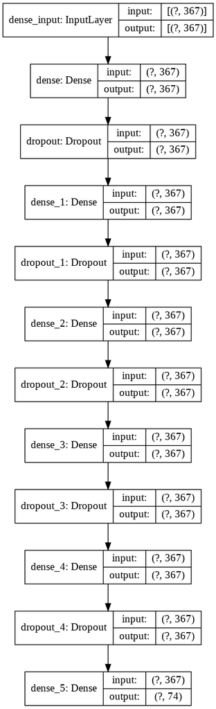

```python
plot_model(model_DNN, to_file='model_plot_model_DNN.png', show_shapes=True, show_layer_names=True)
```

## Analyzing various architectures of DNN

```python
# DNN2 - Analyzing the DNN with input same as DNN1 and hidden with double the nodes of that of the input and 4 layers.
def Model_DNN2(shape, nClasses, dropout=0.5):
    model = Sequential()
    node = maxlen #512 # number of nodes
    nLayers = 4 # hidden layers

    model.add(Dense(node,input_dim=shape,activation='relu'))
    model.add(Dropout(dropout))
    for i in range(0,nLayers):
        model.add(Dense(units = 2*node,activation='relu'))
        model.add(Dropout(dropout))
    model.add(Dense(nClasses, activation='softmax'))
    model.compile(loss='sparse_categorical_crossentropy',
                  optimizer='adam',
                  metrics=['accuracy'])
    model.summary()
    return model

model_DNN2 = Model_DNN2(X_train.shape[1], 74 )

model_DNN2.fit(X_train, y_train,
                              validation_data=(X_test,y_test),
                              epochs=20,
                              batch_size=100,
                              verbose=2)

# Final evaluation of the model
scores_DNN_train = model_DNN2.evaluate(X_train, y_train, verbose=0)
scores_DNN_test = model_DNN2.evaluate(X_test, y_test, verbose=0)
y_pred = model_DNN2.predict(X_test)
print("Train Acc: %.2f%",  (scores_DNN_train[1]*100))
print("Test Acc: %.2f%",  (scores_DNN_test[1]*100))
```

```
Model: "sequential_8"
_________________________________________________________________
Layer (type)                 Output Shape              Param #
=================================================================
dense_23 (Dense)             (None, 367)               135056
_________________________________________________________________
dropout_11 (Dropout)         (None, 367)               0
_________________________________________________________________
dense_24 (Dense)             (None, 734)               270112
_________________________________________________________________
dropout_12 (Dropout)         (None, 734)               0
_________________________________________________________________
dense_25 (Dense)             (None, 734)               539490
_________________________________________________________________
dropout_13 (Dropout)         (None, 734)               0
_________________________________________________________________
dense_26 (Dense)             (None, 734)               539490
_________________________________________________________________
dropout_14 (Dropout)         (None, 734)               0
_________________________________________________________________
dense_27 (Dense)             (None, 734)               539490
_________________________________________________________________
dropout_15 (Dropout)         (None, 734)               0
_________________________________________________________________
dense_28 (Dense)             (None, 74)                54390
=================================================================
Total params: 2,078,028
Trainable params: 2,078,028
Non-trainable params: 0
_________________________________________________________________
510/510 - 23s - loss: 2.4972 - accuracy: 0.3651 - val_loss: 1.1647 - val_accuracy: 0.6670
510/510 - 22s - loss: 1.2005 - accuracy: 0.6491 - val_loss: 0.8317 - val_accuracy: 0.7539
510/510 - 23s - loss: 0.9555 - accuracy: 0.7162 - val_loss: 0.7067 - val_accuracy: 0.7883
510/510 - 22s - loss: 0.8378 - accuracy: 0.7484 - val_loss: 0.6209 - val_accuracy: 0.8100
510/510 - 23s - loss: 0.7769 - accuracy: 0.7647 - val_loss: 0.5927 - val_accuracy: 0.8133
510/510 - 23s - loss: 0.7221 - accuracy: 0.7810 - val_loss: 0.5645 - val_accuracy: 0.8217
510/510 - 22s - loss: 0.6891 - accuracy: 0.7884 - val_loss: 0.5506 - val_accuracy: 0.8210
510/510 - 23s - loss: 0.6698 - accuracy: 0.7938 - val_loss: 0.5342 - val_accuracy: 0.8297
510/510 - 23s - loss: 0.6490 - accuracy: 0.7996 - val_loss: 0.5203 - val_accuracy: 0.8331
510/510 - 23s - loss: 0.6316 - accuracy: 0.8042 - val_loss: 0.5114 - val_accuracy: 0.8314
510/510 - 22s - loss: 0.6226 - accuracy: 0.8071 - val_loss: 0.5023 - val_accuracy: 0.8353
510/510 - 23s - loss: 0.6130 - accuracy: 0.8106 - val_loss: 0.5006 - val_accuracy: 0.8362
510/510 - 23s - loss: 0.5970 - accuracy: 0.8136 - val_loss: 0.4936 - val_accuracy: 0.8356
510/510 - 23s - loss: 0.5944 - accuracy: 0.8151 - val_loss: 0.4862 - val_accuracy: 0.8418
510/510 - 23s - loss: 0.5808 - accuracy: 0.8185 - val_loss: 0.4831 - val_accuracy: 0.8407
510/510 - 23s - loss: 0.5760 - accuracy: 0.8203 - val_loss: 0.4820 - val_accuracy: 0.8413
510/510 - 23s - loss: 0.5727 - accuracy: 0.8202 - val_loss: 0.4784 - val_accuracy: 0.8434
510/510 - 23s - loss: 0.5650 - accuracy: 0.8220 - val_loss: 0.4798 - val_accuracy: 0.8439
510/510 - 26s - loss: 0.5661 - accuracy: 0.8216 - val_loss: 0.4710 - val_accuracy: 0.8448
510/510 - 23s - loss: 0.5588 - accuracy: 0.8245 - val_loss: 0.4725 - val_accuracy: 0.8444
Train Acc: %.2f% 85.32302975654602
Test Acc: %.2f% 84.4449520111084
```

```python
# # predict crisp classes for test set
yhat_classes2 = model_DNN2.predict_classes(X_test, verbose=0)

# precision tp / (tp + fp)
precision = precision_score(y_test, yhat_classes2, average='weighted')
print('Precision: %f' % precision)
# recall: tp / (tp + fn)
recall = recall_score(y_test, yhat_classes2, average='weighted')
print('Recall: %f' % recall)
# f1: 2 tp / (2 tp + fp + fn)
f1 = f1_score(y_test, yhat_classes2, average='weighted')
print('F1 score: %f' % f1)
auc = multiclass_roc_auc_score(y_test, yhat_classes2)
print('ROC AUC: %f' % auc)
```

```
Precision: 0.920082
Recall: 0.844450
F1 score: 0.857862
ROC AUC: 0.921178
```

Using this architecture of DNN, we get a Train accuracy of 85.32% and Test accuracy of 84.44%.

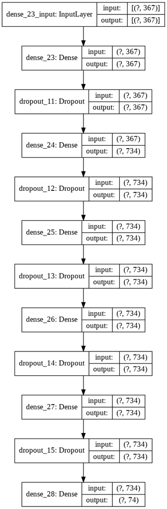

```python
plot_model(model_DNN2, to_file='model_plot_model_DNN2.png', show_shapes=True, show_layer_names=True)
```

```python
# DNN3 - Analyzing the DNN1 with 8 layers

def Model_DNN3(shape, nClasses, dropout=0.5):
    model = Sequential()
    node = maxlen #512 # number of nodes
    nLayers = 8 # number of  hidden layer

    model.add(Dense(node,input_dim=shape,activation='relu'))
    model.add(Dropout(dropout))
    for i in range(0,nLayers):
        model.add(Dense(units = node,activation='relu'))
        model.add(Dropout(dropout))
    model.add(Dense(nClasses, activation='softmax'))
    model.compile(loss='sparse_categorical_crossentropy',
                  optimizer='adam',
                  metrics=['accuracy'])
    model.summary()
    return model

model_DNN3 = Model_DNN3(X_train.shape[1], 74 )

#fit the model
model_DNN3.fit(X_train, y_train,
                              validation_data=(X_test,y_test),
                              epochs=20,
                              batch_size=100,
                              verbose=2)

#evaluate the model
scores_DNN_train = model_DNN3.evaluate(X_train, y_train, verbose=0)
scores_DNN_test = model_DNN3.evaluate(X_test, y_test, verbose=0)
print("Train Acc: %.2f%",  (scores_DNN_train[1]*100))
print("Test Acc: %.2f%",  (scores_DNN_test[1]*100))
```

```
Model: "sequential_9"
_________________________________________________________________
Layer (type)                 Output Shape              Param #
=================================================================
dense_29 (Dense)             (None, 367)               135056
_________________________________________________________________
dropout_16 (Dropout)         (None, 367)               0
_________________________________________________________________
dense_30 (Dense)             (None, 367)               135056
_________________________________________________________________
dropout_17 (Dropout)         (None, 367)               0
_________________________________________________________________
dense_31 (Dense)             (None, 367)               135056
_________________________________________________________________
dropout_18 (Dropout)         (None, 367)               0
_________________________________________________________________
dense_32 (Dense)             (None, 367)               135056
_________________________________________________________________
dropout_19 (Dropout)         (None, 367)               0
_________________________________________________________________
dense_33 (Dense)             (None, 367)               135056
_________________________________________________________________
dropout_20 (Dropout)         (None, 367)               0
_________________________________________________________________
dense_34 (Dense)             (None, 367)               135056
_________________________________________________________________
dropout_21 (Dropout)         (None, 367)               0
_________________________________________________________________
dense_35 (Dense)             (None, 367)               135056
_________________________________________________________________
dropout_22 (Dropout)         (None, 367)               0
_________________________________________________________________
dense_36 (Dense)             (None, 367)               135056
_________________________________________________________________
dropout_23 (Dropout)         (None, 367)               0
_________________________________________________________________
dense_37 (Dense)             (None, 367)               135056
_________________________________________________________________
dropout_24 (Dropout)         (None, 367)               0
_________________________________________________________________
```

[output cut: 13 more lines]

```
510/510 - 15s - loss: 2.2308 - accuracy: 0.2841 - val_loss: 2.1886 - val_accuracy: 0.2825
510/510 - 16s - loss: 2.1668 - accuracy: 0.3064 - val_loss: 2.1138 - val_accuracy: 0.2960
510/510 - 15s - loss: 2.0993 - accuracy: 0.3220 - val_loss: 2.0871 - val_accuracy: 0.3172
510/510 - 15s - loss: 2.0581 - accuracy: 0.3348 - val_loss: 2.0833 - val_accuracy: 0.3325
510/510 - 15s - loss: 2.0044 - accuracy: 0.3492 - val_loss: 2.0077 - val_accuracy: 0.3393
510/510 - 16s - loss: 1.9602 - accuracy: 0.3577 - val_loss: 1.9692 - val_accuracy: 0.3413
510/510 - 15s - loss: 1.9179 - accuracy: 0.3667 - val_loss: 1.8497 - val_accuracy: 0.3684
510/510 - 15s - loss: 1.8894 - accuracy: 0.3738 - val_loss: 1.8260 - val_accuracy: 0.3530
510/510 - 15s - loss: 1.8677 - accuracy: 0.3792 - val_loss: 1.7417 - val_accuracy: 0.3677
510/510 - 15s - loss: 1.8343 - accuracy: 0.3884 - val_loss: 1.7828 - val_accuracy: 0.3649
510/510 - 15s - loss: 1.8203 - accuracy: 0.3923 - val_loss: 1.7458 - val_accuracy: 0.3712
510/510 - 15s - loss: 1.7939 - accuracy: 0.4000 - val_loss: 1.7549 - val_accuracy: 0.3756
510/510 - 15s - loss: 1.7822 - accuracy: 0.4012 - val_loss: 1.7508 - val_accuracy: 0.3762
Train Acc: %.2f% 37.950992584228516
Test Acc: %.2f% 37.61501610279083
```

```python
# # predict crisp classes for test set
yhat_classes3 = model_DNN3.predict_classes(X_test, verbose=0)

# precision tp / (tp + fp)
precision = precision_score(y_test, yhat_classes3, average='weighted')
print('Precision: %f' % precision)
# recall: tp / (tp + fn)
recall = recall_score(y_test, yhat_classes3, average='weighted')
print('Recall: %f' % recall)
# f1: 2 tp / (2 tp + fp + fn)
f1 = f1_score(y_test, yhat_classes3, average='weighted')
print('F1 score: %f' % f1)
auc = multiclass_roc_auc_score(y_test, yhat_classes3)
print('ROC AUC: %f' % auc)
```

```
Precision: 0.354221
Recall: 0.376150
F1 score: 0.326341
ROC AUC: 0.683839
```

Using this architecture of DNN, we get a Train accuracy of 37.95% and Test accuracy of 37.61%.

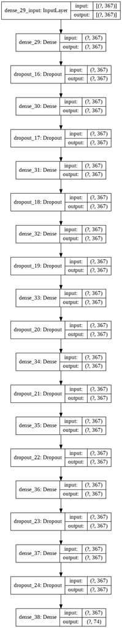

```python
plot_model(model_DNN3, to_file='model_plot_model_DNN3.png', show_shapes=True, show_layer_names=True)
```

```python
# DNN4 - Analyzing the DNN with input same as DNN1 and hidden with double the nodes of that of the input and 8 layers.

def Model_DNN4(shape, nClasses, dropout=0.5):
    model = Sequential()
    node = maxlen #512 # number of nodes
    nLayers = 8 # number of  hidden layer

    model.add(Dense(node,input_dim=shape,activation='relu'))
    model.add(Dropout(dropout))
    for i in range(0,nLayers):
        model.add(Dense(units = 2*node,activation='relu'))
        model.add(Dropout(dropout))
    model.add(Dense(nClasses, activation='softmax'))
    model.compile(loss='sparse_categorical_crossentropy',
                  optimizer='adam',
                  metrics=['accuracy'])
    model.summary()
    return model

model_DNN4 = Model_DNN4(X_train.shape[1], 74 )

#fit the model
model_DNN4.fit(X_train, y_train,
                              validation_data=(X_test,y_test),
                              epochs=20,
                              batch_size=100,
                              verbose=2)

#evaluate the model
scores_DNN_train = model_DNN4.evaluate(X_train, y_train, verbose=0)
scores_DNN_test = model_DNN4.evaluate(X_test, y_test, verbose=0)
print("Train Acc: %.2f%",  (scores_DNN_train[1]*100))
print("Test Acc: %.2f%",  (scores_DNN_test[1]*100))
```

```
Model: "sequential_10"
_________________________________________________________________
Layer (type)                 Output Shape              Param #
=================================================================
dense_39 (Dense)             (None, 367)               135056
_________________________________________________________________
dropout_25 (Dropout)         (None, 367)               0
_________________________________________________________________
dense_40 (Dense)             (None, 734)               270112
_________________________________________________________________
dropout_26 (Dropout)         (None, 734)               0
_________________________________________________________________
dense_41 (Dense)             (None, 734)               539490
_________________________________________________________________
dropout_27 (Dropout)         (None, 734)               0
_________________________________________________________________
dense_42 (Dense)             (None, 734)               539490
_________________________________________________________________
dropout_28 (Dropout)         (None, 734)               0
_________________________________________________________________
dense_43 (Dense)             (None, 734)               539490
_________________________________________________________________
dropout_29 (Dropout)         (None, 734)               0
_________________________________________________________________
dense_44 (Dense)             (None, 734)               539490
_________________________________________________________________
dropout_30 (Dropout)         (None, 734)               0
_________________________________________________________________
dense_45 (Dense)             (None, 734)               539490
_________________________________________________________________
dropout_31 (Dropout)         (None, 734)               0
_________________________________________________________________
dense_46 (Dense)             (None, 734)               539490
_________________________________________________________________
dropout_32 (Dropout)         (None, 734)               0
_________________________________________________________________
dense_47 (Dense)             (None, 734)               539490
_________________________________________________________________
dropout_33 (Dropout)         (None, 734)               0
_________________________________________________________________
```

[output cut: 13 more lines]

```
510/510 - 46s - loss: 1.7219 - accuracy: 0.4294 - val_loss: 1.5196 - val_accuracy: 0.4385
510/510 - 42s - loss: 1.6625 - accuracy: 0.4447 - val_loss: 1.4602 - val_accuracy: 0.4811
510/510 - 43s - loss: 1.5846 - accuracy: 0.4701 - val_loss: 1.4172 - val_accuracy: 0.4889
510/510 - 42s - loss: 1.5458 - accuracy: 0.4850 - val_loss: 1.3162 - val_accuracy: 0.5293
510/510 - 43s - loss: 1.4988 - accuracy: 0.5043 - val_loss: 1.2967 - val_accuracy: 0.5369
510/510 - 42s - loss: 1.4561 - accuracy: 0.5193 - val_loss: 1.2303 - val_accuracy: 0.5656
510/510 - 42s - loss: 1.4172 - accuracy: 0.5295 - val_loss: 1.1997 - val_accuracy: 0.5652
510/510 - 43s - loss: 1.4046 - accuracy: 0.5397 - val_loss: 1.1766 - val_accuracy: 0.5690
510/510 - 43s - loss: 1.3624 - accuracy: 0.5524 - val_loss: 1.1408 - val_accuracy: 0.5899
510/510 - 42s - loss: 1.3380 - accuracy: 0.5660 - val_loss: 1.1078 - val_accuracy: 0.6228
510/510 - 43s - loss: 1.3213 - accuracy: 0.5762 - val_loss: 1.1044 - val_accuracy: 0.6144
510/510 - 44s - loss: 1.3007 - accuracy: 0.5854 - val_loss: 1.0844 - val_accuracy: 0.6177
510/510 - 44s - loss: 1.2673 - accuracy: 0.5955 - val_loss: 1.0633 - val_accuracy: 0.6406
Train Acc: %.2f% 64.79174494743347
Test Acc: %.2f% 64.05584812164307
```

```python
# # predict crisp classes for test set
yhat_classes4 = model_DNN4.predict_classes(X_test, verbose=0)

# precision tp / (tp + fp)
precision = precision_score(y_test, yhat_classes4, average='weighted')
print('Precision: %f' % precision)
# recall: tp / (tp + fn)
recall = recall_score(y_test, yhat_classes4, average='weighted')
print('Recall: %f' % recall)
# f1: 2 tp / (2 tp + fp + fn)
f1 = f1_score(y_test, yhat_classes4, average='weighted')
print('F1 score: %f' % f1)
auc = multiclass_roc_auc_score(y_test, yhat_classes4)
print('ROC AUC: %f' % auc)
```

```
Precision: 0.658741
Recall: 0.640558
F1 score: 0.604978
ROC AUC: 0.817883
```

Using this architecture of DNN, we get a Train accuracy of 64.79% and Test accuracy of 64.05%.

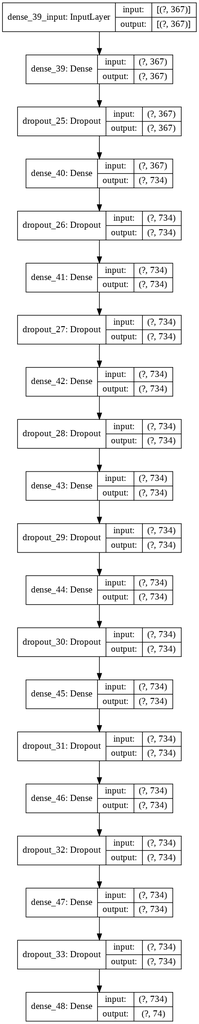

```python
plot_model(model_DNN4, to_file='model_plot_model_DNN4.png', show_shapes=True, show_layer_names=True)
```

```python
# DNN5 - change dropout hyper-paramter
# seems like the Deeper the networks, the accuracy gets worse. Settling on DNN with 4 hidden layers and tuning the other parameters.

def Model_DNN5(shape, nClasses, dropout=0.2):
    model = Sequential()
    node = maxlen #512 # number of nodes
    nLayers = 4 # number of  hidden layer

    model.add(Dense(node,input_dim=shape,activation='relu'))
    model.add(Dropout(dropout))
    for i in range(0,nLayers):
        model.add(Dense(units = node ,activation='relu'))
        model.add(Dropout(dropout))
    model.add(Dense(nClasses, activation='softmax'))
    model.compile(loss='sparse_categorical_crossentropy',
                  optimizer='adam',
                  metrics=['accuracy'])
    model.summary()
    return model

model_DNN5 = Model_DNN5(X_train.shape[1], 74 )

#fit the model
model_DNN5.fit(X_train, y_train,
                              validation_data=(X_test,y_test),
                              epochs=20,
                              batch_size=100,
                              verbose=2)

#evaluate the model
scores_DNN_train = model_DNN5.evaluate(X_train, y_train, verbose=0)
scores_DNN_test = model_DNN5.evaluate(X_test, y_test, verbose=0)
print("Train Acc: %.2f%",  (scores_DNN_train[1]*100))
print("Test Acc: %.2f%",  (scores_DNN_test[1]*100))
```

```
Model: "sequential_11"
_________________________________________________________________
Layer (type)                 Output Shape              Param #
=================================================================
dense_49 (Dense)             (None, 367)               135056
_________________________________________________________________
dropout_34 (Dropout)         (None, 367)               0
_________________________________________________________________
dense_50 (Dense)             (None, 367)               135056
_________________________________________________________________
dropout_35 (Dropout)         (None, 367)               0
_________________________________________________________________
dense_51 (Dense)             (None, 367)               135056
_________________________________________________________________
dropout_36 (Dropout)         (None, 367)               0
_________________________________________________________________
dense_52 (Dense)             (None, 367)               135056
_________________________________________________________________
dropout_37 (Dropout)         (None, 367)               0
_________________________________________________________________
dense_53 (Dense)             (None, 367)               135056
_________________________________________________________________
dropout_38 (Dropout)         (None, 367)               0
_________________________________________________________________
dense_54 (Dense)             (None, 74)                27232
=================================================================
Total params: 702,512
Trainable params: 702,512
Non-trainable params: 0
_________________________________________________________________
510/510 - 9s - loss: 1.6822 - accuracy: 0.5659 - val_loss: 0.8283 - val_accuracy: 0.7587
510/510 - 9s - loss: 0.7748 - accuracy: 0.7688 - val_loss: 0.5949 - val_accuracy: 0.8126
510/510 - 9s - loss: 0.6250 - accuracy: 0.8069 - val_loss: 0.5392 - val_accuracy: 0.8299
510/510 - 12s - loss: 0.5626 - accuracy: 0.8223 - val_loss: 0.5104 - val_accuracy: 0.8363
510/510 - 9s - loss: 0.5277 - accuracy: 0.8322 - val_loss: 0.4877 - val_accuracy: 0.8396
510/510 - 9s - loss: 0.5053 - accuracy: 0.8358 - val_loss: 0.4922 - val_accuracy: 0.8424
510/510 - 9s - loss: 0.4917 - accuracy: 0.8405 - val_loss: 0.4748 - val_accuracy: 0.8433
510/510 - 9s - loss: 0.4817 - accuracy: 0.8424 - val_loss: 0.4733 - val_accuracy: 0.8442
510/510 - 9s - loss: 0.4697 - accuracy: 0.8448 - val_loss: 0.4674 - val_accuracy: 0.8484
510/510 - 9s - loss: 0.4642 - accuracy: 0.8466 - val_loss: 0.4664 - val_accuracy: 0.8478
510/510 - 9s - loss: 0.4601 - accuracy: 0.8476 - val_loss: 0.4653 - val_accuracy: 0.8474
510/510 - 9s - loss: 0.4585 - accuracy: 0.8478 - val_loss: 0.4663 - val_accuracy: 0.8472
510/510 - 9s - loss: 0.4508 - accuracy: 0.8507 - val_loss: 0.4612 - val_accuracy: 0.8512
510/510 - 9s - loss: 0.4468 - accuracy: 0.8512 - val_loss: 0.4669 - val_accuracy: 0.8481
510/510 - 9s - loss: 0.4437 - accuracy: 0.8522 - val_loss: 0.4575 - val_accuracy: 0.8528
510/510 - 9s - loss: 0.4424 - accuracy: 0.8513 - val_loss: 0.4697 - val_accuracy: 0.8482
510/510 - 9s - loss: 0.4452 - accuracy: 0.8534 - val_loss: 0.4650 - val_accuracy: 0.8511
510/510 - 9s - loss: 0.4344 - accuracy: 0.8542 - val_loss: 0.4616 - val_accuracy: 0.8514
510/510 - 9s - loss: 0.4335 - accuracy: 0.8539 - val_loss: 0.4557 - val_accuracy: 0.8493
510/510 - 9s - loss: 0.4336 - accuracy: 0.8557 - val_loss: 0.4606 - val_accuracy: 0.8505
Train Acc: %.2f% 86.14113926887512
Test Acc: %.2f% 85.04921197891235
```

```python
# # predict crisp classes for test set
yhat_classes5 = model_DNN5.predict_classes(X_test, verbose=0)

# precision tp / (tp + fp)
precision = precision_score(y_test, yhat_classes5, average='weighted')
print('Precision: %f' % precision)
# recall: tp / (tp + fn)
recall = recall_score(y_test, yhat_classes5, average='weighted')
print('Recall: %f' % recall)
# f1: 2 tp / (2 tp + fp + fn)
f1 = f1_score(y_test, yhat_classes5, average='weighted')
print('F1 score: %f' % f1)
auc = multiclass_roc_auc_score(y_test, yhat_classes5)
print('ROC AUC: %f' % auc)
```

```
Precision: 0.929500
Recall: 0.850492
F1 score: 0.865022
ROC AUC: 0.924264
```

Using this architecture of DNN, we get a Train accuracy of 86.14% and Test accuracy of 85.04%.

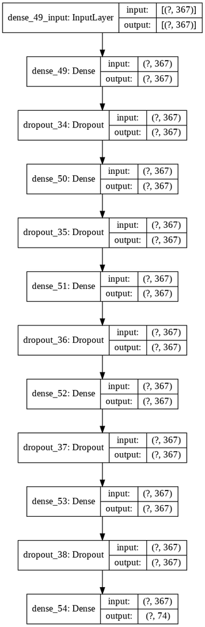

```python
plot_model(model_DNN5, to_file='model_plot_model_DNN5.png', show_shapes=True, show_layer_names=True)
```

```python
# DNN6 - remove dropout layers

def Model_DNN6(shape, nClasses):
    model = Sequential()
    node = maxlen #512 # number of nodes
    nLayers = 4 # number of  hidden layer

    model.add(Dense(node,input_dim=shape,activation='relu'))
    for i in range(0,nLayers):
        model.add(Dense(units = node,activation='relu'))
    model.add(Dense(nClasses, activation='softmax'))
    model.compile(loss='sparse_categorical_crossentropy',
                  optimizer='adam',
                  metrics=['accuracy'])
    model.summary()
    return model

Model_DNN6 = Model_DNN6(X_train.shape[1], 74 )

#fit the model
Model_DNN6.fit(X_train, y_train,
                              validation_data=(X_test,y_test),
                              epochs=20,
                              batch_size=100,
                              verbose=2)

#evaluate the model
scores_DNN_train = Model_DNN6.evaluate(X_train, y_train, verbose=0)
scores_DNN_test = Model_DNN6.evaluate(X_test, y_test, verbose=0)
print("Train Acc: %.2f%",  (scores_DNN_train[1]*100))
print("Test Acc: %.2f%",  (scores_DNN_test[1]*100))
```

```
Model: "sequential_15"
_________________________________________________________________
Layer (type)                 Output Shape              Param #
=================================================================
dense_67 (Dense)             (None, 367)               135056
_________________________________________________________________
dense_68 (Dense)             (None, 367)               135056
_________________________________________________________________
dense_69 (Dense)             (None, 367)               135056
_________________________________________________________________
dense_70 (Dense)             (None, 367)               135056
_________________________________________________________________
dense_71 (Dense)             (None, 367)               135056
_________________________________________________________________
dense_72 (Dense)             (None, 74)                27232
=================================================================
Total params: 702,512
Trainable params: 702,512
Non-trainable params: 0
_________________________________________________________________
510/510 - 8s - loss: 1.3055 - accuracy: 0.6579 - val_loss: 0.7219 - val_accuracy: 0.7875
510/510 - 8s - loss: 0.6008 - accuracy: 0.8140 - val_loss: 0.5606 - val_accuracy: 0.8254
510/510 - 8s - loss: 0.5094 - accuracy: 0.8362 - val_loss: 0.5354 - val_accuracy: 0.8302
510/510 - 8s - loss: 0.4782 - accuracy: 0.8445 - val_loss: 0.5324 - val_accuracy: 0.8281
510/510 - 8s - loss: 0.4720 - accuracy: 0.8449 - val_loss: 0.4964 - val_accuracy: 0.8402
510/510 - 8s - loss: 0.4519 - accuracy: 0.8489 - val_loss: 0.4951 - val_accuracy: 0.8431
510/510 - 7s - loss: 0.4430 - accuracy: 0.8520 - val_loss: 0.4859 - val_accuracy: 0.8371
510/510 - 8s - loss: 0.4434 - accuracy: 0.8513 - val_loss: 0.4897 - val_accuracy: 0.8461
510/510 - 7s - loss: 0.4347 - accuracy: 0.8533 - val_loss: 0.4645 - val_accuracy: 0.8508
510/510 - 8s - loss: 0.4320 - accuracy: 0.8548 - val_loss: 0.4827 - val_accuracy: 0.8437
510/510 - 8s - loss: 0.4356 - accuracy: 0.8542 - val_loss: 0.4765 - val_accuracy: 0.8463
510/510 - 7s - loss: 0.4224 - accuracy: 0.8578 - val_loss: 0.4761 - val_accuracy: 0.8473
510/510 - 7s - loss: 0.4288 - accuracy: 0.8554 - val_loss: 0.4848 - val_accuracy: 0.8462
510/510 - 7s - loss: 0.4188 - accuracy: 0.8584 - val_loss: 0.5021 - val_accuracy: 0.8437
510/510 - 7s - loss: 0.4194 - accuracy: 0.8577 - val_loss: 0.4694 - val_accuracy: 0.8500
510/510 - 7s - loss: 0.4275 - accuracy: 0.8553 - val_loss: 0.4695 - val_accuracy: 0.8493
510/510 - 8s - loss: 0.4095 - accuracy: 0.8595 - val_loss: 0.4648 - val_accuracy: 0.8477
510/510 - 7s - loss: 0.4164 - accuracy: 0.8590 - val_loss: 0.4787 - val_accuracy: 0.8463
510/510 - 8s - loss: 0.4178 - accuracy: 0.8585 - val_loss: 0.4752 - val_accuracy: 0.8484
510/510 - 8s - loss: 0.4080 - accuracy: 0.8611 - val_loss: 0.4690 - val_accuracy: 0.8501
Train Acc: %.2f% 86.17056608200073
Test Acc: %.2f% 85.01259088516235
```

```python
# # predict crisp classes for test set
yhat_classes6 = Model_DNN6.predict_classes(X_test, verbose=0)

# precision tp / (tp + fp)
precision = precision_score(y_test, yhat_classes6, average='weighted')
print('Precision: %f' % precision)
# recall: tp / (tp + fn)
recall = recall_score(y_test, yhat_classes6, average='weighted')
print('Recall: %f' % recall)
# f1: 2 tp / (2 tp + fp + fn)
f1 = f1_score(y_test, yhat_classes6, average='weighted')
print('F1 score: %f' % f1)
auc = multiclass_roc_auc_score(y_test, yhat_classes6)
print('ROC AUC: %f' % auc)
```

```
Precision: 0.930041
Recall: 0.850126
F1 score: 0.865961
ROC AUC: 0.924102
```

Using this architecture of DNN, we get a Train accuracy of 86.17% and Test accuracy of 85.01%.

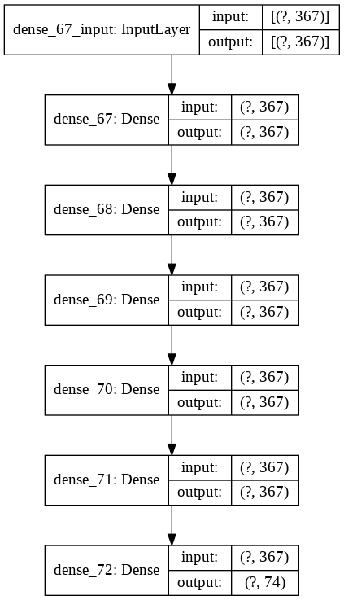

```python
plot_model(Model_DNN6, to_file='model_plot_model_DNN6.png', show_shapes=True, show_layer_names=True)
```

```python
# NN7 - Simple NN - 1 input, 1 output and 1 hidden layer and no dropout.

def Model_NN(shape, nClasses):
    model = Sequential()
    node = maxlen #512 # number of nodes

    model.add(Dense(node,input_dim=shape,activation='relu'))
    model.add(Dense(units = node,activation='relu'))
    model.add(Dense(nClasses, activation='softmax'))
    model.compile(loss='sparse_categorical_crossentropy',
                  optimizer='adam',
                  metrics=['accuracy'])
    model.summary()
    return model

Model_NN = Model_NN(X_train.shape[1], 74 )

#fit the model
Model_NN.fit(X_train, y_train,
                              validation_data=(X_test,y_test),
                              epochs=20,
                              batch_size=100,
                              verbose=2)

#evaluate the model
scores_DNN_train = Model_NN.evaluate(X_train, y_train, verbose=0)
scores_DNN_test = Model_NN.evaluate(X_test, y_test, verbose=0)
print("Train Acc: %.2f%",  (scores_DNN_train[1]*100))
print("Test Acc: %.2f%",  (scores_DNN_test[1]*100))
```

```
Model: "sequential_12"
_________________________________________________________________
Layer (type)                 Output Shape              Param #
=================================================================
dense_55 (Dense)             (None, 367)               135056
_________________________________________________________________
dense_56 (Dense)             (None, 367)               135056
_________________________________________________________________
dense_57 (Dense)             (None, 74)                27232
=================================================================
Total params: 297,344
Trainable params: 297,344
Non-trainable params: 0
_________________________________________________________________
510/510 - 4s - loss: 1.5427 - accuracy: 0.6370 - val_loss: 0.8608 - val_accuracy: 0.7493
510/510 - 4s - loss: 0.7220 - accuracy: 0.7857 - val_loss: 0.6775 - val_accuracy: 0.7924
510/510 - 4s - loss: 0.6004 - accuracy: 0.8129 - val_loss: 0.5884 - val_accuracy: 0.8198
510/510 - 4s - loss: 0.5401 - accuracy: 0.8288 - val_loss: 0.5571 - val_accuracy: 0.8217
510/510 - 4s - loss: 0.5035 - accuracy: 0.8380 - val_loss: 0.5181 - val_accuracy: 0.8355
510/510 - 4s - loss: 0.4795 - accuracy: 0.8436 - val_loss: 0.5042 - val_accuracy: 0.8373
510/510 - 4s - loss: 0.4663 - accuracy: 0.8464 - val_loss: 0.4981 - val_accuracy: 0.8344
510/510 - 4s - loss: 0.4540 - accuracy: 0.8509 - val_loss: 0.4775 - val_accuracy: 0.8426
510/510 - 4s - loss: 0.4463 - accuracy: 0.8522 - val_loss: 0.4698 - val_accuracy: 0.8483
510/510 - 4s - loss: 0.4404 - accuracy: 0.8538 - val_loss: 0.4720 - val_accuracy: 0.8430
510/510 - 4s - loss: 0.4344 - accuracy: 0.8542 - val_loss: 0.4694 - val_accuracy: 0.8455
510/510 - 4s - loss: 0.4308 - accuracy: 0.8555 - val_loss: 0.4667 - val_accuracy: 0.8434
510/510 - 4s - loss: 0.4273 - accuracy: 0.8567 - val_loss: 0.4661 - val_accuracy: 0.8472
510/510 - 4s - loss: 0.4258 - accuracy: 0.8566 - val_loss: 0.4635 - val_accuracy: 0.8488
510/510 - 4s - loss: 0.4214 - accuracy: 0.8590 - val_loss: 0.4628 - val_accuracy: 0.8477
510/510 - 4s - loss: 0.4215 - accuracy: 0.8586 - val_loss: 0.4688 - val_accuracy: 0.8481
510/510 - 4s - loss: 0.4196 - accuracy: 0.8583 - val_loss: 0.4536 - val_accuracy: 0.8511
510/510 - 4s - loss: 0.4163 - accuracy: 0.8590 - val_loss: 0.4623 - val_accuracy: 0.8473
510/510 - 4s - loss: 0.4165 - accuracy: 0.8593 - val_loss: 0.4541 - val_accuracy: 0.8501
510/510 - 4s - loss: 0.4157 - accuracy: 0.8588 - val_loss: 0.4589 - val_accuracy: 0.8498
Train Acc: %.2f% 86.09797954559326
Test Acc: %.2f% 84.97596979141235
```

```python
# # predict crisp classes for test set
yhat_classes7 = Model_NN.predict_classes(X_test, verbose=0)

# precision tp / (tp + fp)
precision = precision_score(y_test, yhat_classes7, average='weighted')
print('Precision: %f' % precision)
# recall: tp / (tp + fn)
recall = recall_score(y_test, yhat_classes7, average='weighted')
print('Recall: %f' % recall)
# f1: 2 tp / (2 tp + fp + fn)
f1 = f1_score(y_test, yhat_classes7, average='weighted')
print('F1 score: %f' % f1)
auc = multiclass_roc_auc_score(y_test, yhat_classes7)
print('ROC AUC: %f' % auc)
```

```
Precision: 0.932609
Recall: 0.849760
F1 score: 0.864783
ROC AUC: 0.923893
```

Using this architecture of NN, we get a Train accuracy of 86.09% and Test accuracy of 84.97%.

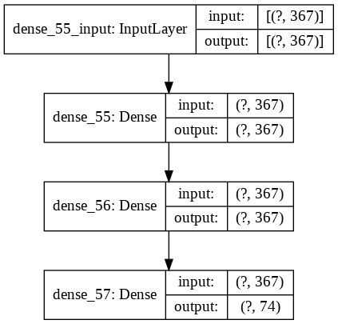

```python
plot_model(Model_NN, to_file='model_plot_model_NN.png', show_shapes=True, show_layer_names=True)
```

```python
# DNN8 - Activation funciton is sigmoid instead of relu

def Model_DNN8(shape, nClasses):
    model = Sequential()
    node = maxlen #512 # number of nodes

    model.add(Dense(node,input_dim=shape,activation='sigmoid'))
    model.add(Dense(units = node,activation='sigmoid'))
    model.add(Dense(nClasses, activation='softmax'))
    model.compile(loss='sparse_categorical_crossentropy',
                  optimizer='adam',
                  metrics=['accuracy'])
    model.summary()
    return model

Model_DNN8 = Model_DNN8(X_train.shape[1], 74 )

#fit the model
Model_DNN8.fit(X_train, y_train,
                              validation_data=(X_test,y_test),
                              epochs=20,
                              batch_size=100,
                              verbose=2)

#evaluate the model
scores_DNN_train = Model_DNN8.evaluate(X_train, y_train, verbose=0)
scores_DNN_test = Model_DNN8.evaluate(X_test, y_test, verbose=0)
print("Train Acc: %.2f%",  (scores_DNN_train[1]*100))
print("Test Acc: %.2f%",  (scores_DNN_test[1]*100))
```

```
Model: "sequential_13"
_________________________________________________________________
Layer (type)                 Output Shape              Param #
=================================================================
dense_58 (Dense)             (None, 367)               135056
_________________________________________________________________
dense_59 (Dense)             (None, 367)               135056
_________________________________________________________________
dense_60 (Dense)             (None, 74)                27232
=================================================================
Total params: 297,344
Trainable params: 297,344
Non-trainable params: 0
_________________________________________________________________
510/510 - 4s - loss: 3.7968 - accuracy: 0.1747 - val_loss: 2.6480 - val_accuracy: 0.4042
510/510 - 4s - loss: 1.9481 - accuracy: 0.5290 - val_loss: 1.5261 - val_accuracy: 0.6153
510/510 - 4s - loss: 1.3433 - accuracy: 0.6364 - val_loss: 1.2557 - val_accuracy: 0.6614
510/510 - 4s - loss: 1.1262 - accuracy: 0.6836 - val_loss: 1.0762 - val_accuracy: 0.6938
510/510 - 4s - loss: 1.0034 - accuracy: 0.7125 - val_loss: 0.9913 - val_accuracy: 0.7149
510/510 - 4s - loss: 0.9241 - accuracy: 0.7327 - val_loss: 0.9189 - val_accuracy: 0.7393
510/510 - 4s - loss: 0.8609 - accuracy: 0.7496 - val_loss: 0.8798 - val_accuracy: 0.7401
510/510 - 4s - loss: 0.8170 - accuracy: 0.7597 - val_loss: 0.8499 - val_accuracy: 0.7402
510/510 - 4s - loss: 0.7819 - accuracy: 0.7681 - val_loss: 0.7841 - val_accuracy: 0.7720
510/510 - 4s - loss: 0.7474 - accuracy: 0.7762 - val_loss: 0.7713 - val_accuracy: 0.7686
510/510 - 4s - loss: 0.7200 - accuracy: 0.7831 - val_loss: 0.7455 - val_accuracy: 0.7780
510/510 - 4s - loss: 0.6967 - accuracy: 0.7907 - val_loss: 0.7279 - val_accuracy: 0.7892
510/510 - 4s - loss: 0.6770 - accuracy: 0.7958 - val_loss: 0.6908 - val_accuracy: 0.7937
510/510 - 4s - loss: 0.6552 - accuracy: 0.8010 - val_loss: 0.6810 - val_accuracy: 0.7991
510/510 - 4s - loss: 0.6398 - accuracy: 0.8041 - val_loss: 0.6692 - val_accuracy: 0.7948
510/510 - 4s - loss: 0.6235 - accuracy: 0.8090 - val_loss: 0.6437 - val_accuracy: 0.8016
510/510 - 4s - loss: 0.6098 - accuracy: 0.8120 - val_loss: 0.6364 - val_accuracy: 0.8026
510/510 - 4s - loss: 0.5964 - accuracy: 0.8151 - val_loss: 0.6301 - val_accuracy: 0.8068
510/510 - 4s - loss: 0.5843 - accuracy: 0.8184 - val_loss: 0.6143 - val_accuracy: 0.8087
510/510 - 4s - loss: 0.5738 - accuracy: 0.8202 - val_loss: 0.6028 - val_accuracy: 0.8177
Train Acc: %.2f% 83.00013542175293
Test Acc: %.2f% 81.7669928073883
```

```python
# # predict crisp classes for test set
yhat_classes8 = Model_DNN8.predict_classes(X_test, verbose=0)

# precision tp / (tp + fp)
precision = precision_score(y_test, yhat_classes8, average='weighted')
print('Precision: %f' % precision)
# recall: tp / (tp + fn)
recall = recall_score(y_test, yhat_classes8, average='weighted')
print('Recall: %f' % recall)
# f1: 2 tp / (2 tp + fp + fn)
f1 = f1_score(y_test, yhat_classes8, average='weighted')
print('F1 score: %f' % f1)
auc = multiclass_roc_auc_score(y_test, yhat_classes8)
print('ROC AUC: %f' % auc)
```

```
Precision: 0.891679
Recall: 0.817670
F1 score: 0.829018
ROC AUC: 0.907653
```

Using this architecture of DNN, we get a Train accuracy of 83.00% and Test accuracy of 81.76%.

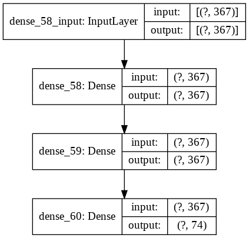

```python
plot_model(Model_DNN8, to_file='model_plot_model_DNN8.png', show_shapes=True, show_layer_names=True)
```

```python
# DNN9 - change dropout hyper-paramter
# seems like the Deeper the networks, the accuracy gets worse. Settling on DNN with 4 hidden layers and tuning the other parameters.
# Reducing the hidden nodes by half the input no

def Model_DNN9(shape, nClasses, dropout=0.2):
    model = Sequential()
    node = maxlen #512 # number of nodes
    nLayers = 4 # number of  hidden layer

    model.add(Dense(node,input_dim=shape,activation='relu'))
    model.add(Dropout(dropout))
    for i in range(0,nLayers):
        model.add(Dense(units = node/2,activation='relu'))
        model.add(Dropout(dropout))
    model.add(Dense(nClasses, activation='softmax'))
    model.compile(loss='sparse_categorical_crossentropy',
                  optimizer='adam',
                  metrics=['accuracy'])
    model.summary()
    return model

Model_DNN9 = Model_DNN5(X_train.shape[1], 74 )

#fit the model
Model_DNN9.fit(X_train, y_train,
                              validation_data=(X_test,y_test),
                              epochs=20,
                              batch_size=100,
                              verbose=2)

#evaluate the model
scores_DNN_train = Model_DNN9.evaluate(X_train, y_train, verbose=0)
scores_DNN_test = Model_DNN9.evaluate(X_test, y_test, verbose=0)
print("Train Acc: %.2f%",  (scores_DNN_train[1]*100))
print("Test Acc: %.2f%",  (scores_DNN_test[1]*100))
```

```
Model: "sequential_14"
_________________________________________________________________
Layer (type)                 Output Shape              Param #
=================================================================
dense_61 (Dense)             (None, 367)               135056
_________________________________________________________________
dropout_39 (Dropout)         (None, 367)               0
_________________________________________________________________
dense_62 (Dense)             (None, 367)               135056
_________________________________________________________________
dropout_40 (Dropout)         (None, 367)               0
_________________________________________________________________
dense_63 (Dense)             (None, 367)               135056
_________________________________________________________________
dropout_41 (Dropout)         (None, 367)               0
_________________________________________________________________
dense_64 (Dense)             (None, 367)               135056
_________________________________________________________________
dropout_42 (Dropout)         (None, 367)               0
_________________________________________________________________
dense_65 (Dense)             (None, 367)               135056
_________________________________________________________________
dropout_43 (Dropout)         (None, 367)               0
_________________________________________________________________
dense_66 (Dense)             (None, 74)                27232
=================================================================
Total params: 702,512
Trainable params: 702,512
Non-trainable params: 0
_________________________________________________________________
510/510 - 9s - loss: 1.6815 - accuracy: 0.5656 - val_loss: 0.7837 - val_accuracy: 0.7706
510/510 - 9s - loss: 0.7629 - accuracy: 0.7737 - val_loss: 0.6011 - val_accuracy: 0.8088
510/510 - 9s - loss: 0.6183 - accuracy: 0.8087 - val_loss: 0.5493 - val_accuracy: 0.8260
510/510 - 9s - loss: 0.5609 - accuracy: 0.8225 - val_loss: 0.5127 - val_accuracy: 0.8356
510/510 - 12s - loss: 0.5274 - accuracy: 0.8312 - val_loss: 0.4965 - val_accuracy: 0.8409
510/510 - 9s - loss: 0.5079 - accuracy: 0.8363 - val_loss: 0.4813 - val_accuracy: 0.8428
510/510 - 9s - loss: 0.4942 - accuracy: 0.8382 - val_loss: 0.4753 - val_accuracy: 0.8425
510/510 - 9s - loss: 0.4789 - accuracy: 0.8434 - val_loss: 0.4704 - val_accuracy: 0.8441
510/510 - 9s - loss: 0.4768 - accuracy: 0.8434 - val_loss: 0.4710 - val_accuracy: 0.8431
510/510 - 9s - loss: 0.4724 - accuracy: 0.8460 - val_loss: 0.4611 - val_accuracy: 0.8461
510/510 - 9s - loss: 0.4634 - accuracy: 0.8478 - val_loss: 0.4642 - val_accuracy: 0.8460
510/510 - 9s - loss: 0.4595 - accuracy: 0.8485 - val_loss: 0.4641 - val_accuracy: 0.8471
510/510 - 9s - loss: 0.4539 - accuracy: 0.8492 - val_loss: 0.4583 - val_accuracy: 0.8481
510/510 - 9s - loss: 0.4508 - accuracy: 0.8494 - val_loss: 0.4583 - val_accuracy: 0.8493
510/510 - 9s - loss: 0.4446 - accuracy: 0.8512 - val_loss: 0.4596 - val_accuracy: 0.8489
510/510 - 9s - loss: 0.4440 - accuracy: 0.8518 - val_loss: 0.4518 - val_accuracy: 0.8485
510/510 - 9s - loss: 0.4447 - accuracy: 0.8518 - val_loss: 0.4584 - val_accuracy: 0.8489
510/510 - 9s - loss: 0.4404 - accuracy: 0.8533 - val_loss: 0.4529 - val_accuracy: 0.8509
510/510 - 9s - loss: 0.4363 - accuracy: 0.8533 - val_loss: 0.4561 - val_accuracy: 0.8506
510/510 - 9s - loss: 0.4319 - accuracy: 0.8547 - val_loss: 0.4618 - val_accuracy: 0.8482
Train Acc: %.2f% 86.05285286903381
Test Acc: %.2f% 84.82490181922913
```

```python
# # predict crisp classes for test set
yhat_classes9 = Model_DNN9.predict_classes(X_test, verbose=0)

# precision tp / (tp + fp)
precision = precision_score(y_test, yhat_classes9, average='weighted')
print('Precision: %f' % precision)
# recall: tp / (tp + fn)
recall = recall_score(y_test, yhat_classes9, average='weighted')
print('Recall: %f' % recall)
# f1: 2 tp / (2 tp + fp + fn)
f1 = f1_score(y_test, yhat_classes9, average='weighted')
print('F1 score: %f' % f1)
auc = multiclass_roc_auc_score(y_test, yhat_classes9)
print('ROC AUC: %f' % auc)
```

```
Precision: 0.929909
Recall: 0.848249
F1 score: 0.863006
ROC AUC: 0.923152
```

Using this architecture of DNN, we get a Train accuracy of 86.05% and Test accuracy of 84.82%.

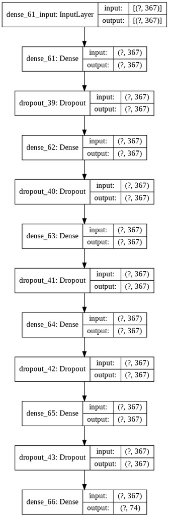

```python
plot_model(Model_DNN9, to_file='model_plot_model_DNN9.png', show_shapes=True, show_layer_names=True)
```

## RCNN

```python
def RCNN_model():
    model = Sequential()
    model.add(Embedding(vocab_size, output_dim=100, input_length=maxlen))
    model.add(Dropout(0.25))
    model.add(Conv1D(filters=250,
                 kernel_size=3,
                 padding='valid',
                 activation='relu',
                 strides=1))
    model.add(MaxPooling1D())
    model.add(LSTM(128))
    model.add(Dense(74))
    model.add(Activation('softmax'))

    model.compile(loss='sparse_categorical_crossentropy',
              optimizer='adam',
              metrics=['accuracy'])
    model.summary()

    return model

RCNN_model = RCNN_model()

print('Train...')
RCNN_model.fit(X_train_p, y_train_p,
          batch_size=300,
          epochs=20,
          validation_data=(X_test_p, y_test_p))
score_train, acc_train = RCNN_model.evaluate(X_train_p, y_train_p,
                            batch_size=300)
score, acc = RCNN_model.evaluate(X_test_p, y_test_p,
                            batch_size=300)

print('Test...')
```

```
Model: "sequential_2"
_________________________________________________________________
Layer (type)                 Output Shape              Param #
=================================================================
embedding_2 (Embedding)      (None, 367, 100)          256200
_________________________________________________________________
dropout_1 (Dropout)          (None, 367, 100)          0
_________________________________________________________________
conv1d_1 (Conv1D)            (None, 365, 250)          75250
_________________________________________________________________
max_pooling1d_1 (MaxPooling1 (None, 182, 250)          0
_________________________________________________________________
lstm_2 (LSTM)                (None, 128)               194048
_________________________________________________________________
dense_3 (Dense)              (None, 74)                9546
_________________________________________________________________
activation_1 (Activation)    (None, 74)                0
=================================================================
Total params: 535,044
Trainable params: 535,044
Non-trainable params: 0
_________________________________________________________________
Train...
Test...
```

```python
print('Train accuracy:', acc_train)
print('Test accuracy:', acc)
loc = result_df[result_df['Model']=='RCNN'].index
result_df['Test_Accuracy'][loc] = acc
```

```
Train accuracy: 0.8854250311851501
Test accuracy: 0.8736553192138672
```

```python
# # predict crisp classes for test set
yhat_classes = RCNN_model.predict_classes(X_test_p, verbose=0)

# precision tp / (tp + fp)
precision = precision_score(y_test_p, yhat_classes, average='weighted')
print('Precision: %f' % precision)
# recall: tp / (tp + fn)
recall = recall_score(y_test_p, yhat_classes, average='weighted')
print('Recall: %f' % recall)
# f1: 2 tp / (2 tp + fp + fn)
f1 = f1_score(y_test_p, yhat_classes, average='weighted')
print('F1 score: %f' % f1)
```

```
Precision: 0.956211
Recall: 0.873655
F1 score: 0.887674
```

```python
auc = multiclass_roc_auc_score(y_test_p, yhat_classes)
print('ROC AUC: %f' % auc)
```

```
ROC AUC: 0.936001
```

Using RCNN, we get a Train accuracy of 88.54% and Test accuracy of 87.36%.

```python
result_df
```

|  | Model | Test_Accuracy |
| --- | --- | --- |
| 0 | NB | 0.5916 |
| 1 | SVM | 0.599 |
| 2 | D-Tree | 0.5191 |
| 3 | RandomForest | 0.5865 |
| 4 | Bagging_Ensemble | 0.61 |
| 5 | Boosting_Ensemble | 0.58 |
| 6 | LSTM | 0.8885 |
| 7 | DNN | 0.8396 |
| 8 | RCNN | 0.8736 |

```
-------------------------  MODELS RESULT  ----------------------
               Model Test_Accuracy
0                 NB        0.5916
1                SVM         0.599
2             D-Tree        0.5191
3       RandomForest        0.5865
4   Bagging_Ensemble          0.61
5  Boosting_Ensemble          0.58
6               LSTM        0.8885
7                DNN        0.8396
8               RCNN        0.8736
```

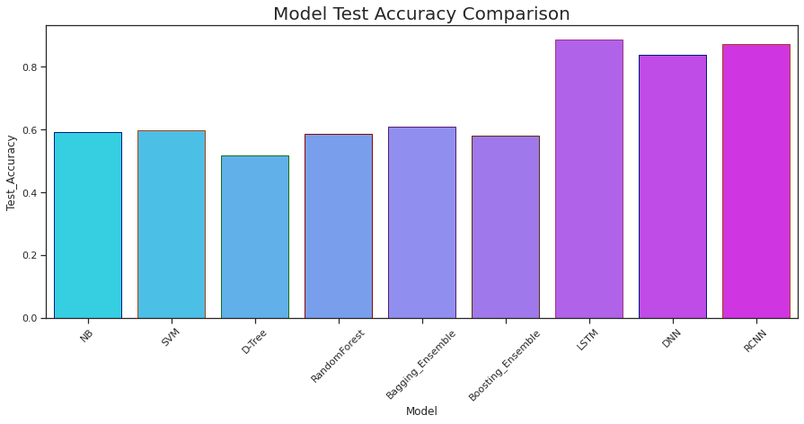

```python
#plotting resultdf for comparison of test accuracy among all models
print("\n" + "*"*65 + "\n")
print("-------------------------  MODELS RESULT  ----------------------")
print(result_df)
print("\n" + "*"*65 + "\n")

# Model Comparison - For Training Accuracy
plt.figure(1)
plt.subplots(figsize=(15,6))
sns.barplot(x="Model", y="Test_Accuracy",data=result_df,palette='cool',edgecolor=sns.color_palette('dark',7))
plt.xticks(rotation=45)
plt.title('Model Test Accuracy Comparison', fontsize=20)
plt.show()
```

From the visualization above, it is observed that LSTM gives the best test accuracy for the above problem

### Model Summary

| Model | Accuracy (Train) | Accuracy(Test) | Precision | Recall | F1 score |
| --- | --- | --- | --- | --- | --- |
| Naive Bayes(Multinomial) | 67.48 | 59.16 | 49.20 | 59.16 | 68.25 |
| SVC(kernel='linear') | 80.81 | 59.90 | 53.34 | 59.90 | 65.26 |
| Decision Tree | 88.47 | 51.91 | 46.52 | 51.91 | 55.94 |
| Random Forest | 88.45 | 58.65 | 50.23 | 58.65 | 67.47 |
| Ensemble(Bagging) | - | 61 | - | - | - |
| Ensemble(Boosting) | - | 58 | - | - | - |
| Naive Bayes(Multinomial) (hyperparameter) | 67.48 | 59.13 | 49.10 | 59.13 | 68.25 |
| SVM(hyperparameter) | 73.62 | 59.04 | 54.87 | 59.04 | 69.95 |
| Decision Tree(hyperparameter) | 62.45 | 55.44 | 44.00 | 55.44 | 66.55 |
| Random Forest(hyperparameter) | 88.47 | 59.96 | 51.41 | 59.96 | 67.74 |
| LSTM | 89.98 | 88.85 | 95.72 | 88.85 | 90.01 |
| DNN | 85.16 | 83.96 | 91.75 | 83.96 | 85.55 |
| DNN2 | 85.32 | 84.44 | 92.00 | 84.44 | 85.78 |
| DNN3 | 37.95 | 37.61 | 35.42 | 37.61 | 32.63 |
| DNN4 | 64.79 | 64.05 | 65.87 | 64.05 | 60.49 |
| DNN5 | 86.14 | 85.04 | 92.95 | 85.04 | 86.50 |
| DNN6 | 86.17 | 85.01 | 93.00 | 85.01 | 86.59 |
| NN | 86.09 | 84.97 | 93.26 | 84.97 | 86.47 |
| DNN8 | 83.00 | 81.76 | 89.16 | 81.76 | 82.90 |
| DNN9 | 86.05 | 84.82 | 92.99 | 84.82 | 86.30 |
| RCNN | 88.54 | 87.36 | 95.62 | 87.36 | 88.76 |